# Kostenoffenlegung als Wettbewerbsvorteil

Chancen und Potenziale der Kostentransparenz

# Motivation

Die Untersuchung von Kostentransparenz ist aus ökonomischer Sicht besonders spannend, da sie Einblicke in das Zusammenspiel von Marktverhalten, Preiswahrnehmung und Konsumentenvertrauen ermöglicht. In klassischen Märkten gilt Information als asymmetrisch verteilt - insbesondere Kostenstrukturen bleiben für Konsument:innen meist verborgen. Wenn Unternehmen jedoch freiwillig ihre Produktionskosten offenlegen, entsteht eine neue Form der Marktkommunikation, die sowohl auf das Kaufverhalten als auch auf die Markenbindung Einfluss nehmen kann.

In diesem Projekt beschäftigen Sie sich mit der ökonomischen Wirkung unterschiedlicher Formen von Kostentransparenz, darunter produktbezogene Einzelkosten-Offenlegung im Point-of-Sale oder auch verbal vermittelte Transparenz in Kombination mit Vertrauensmessung. Ziel ist es, zu untersuchen, wie sich diese Varianten auf Zahlungsbereitschaft, Vertrauen und wahrgenommene Preisfairness auswirken.

Kern dieser Ausarbeitung ist die Frage, inwiefern Kostentransparenz eine rationale Kaufentscheidung unterstützt oder über emotionale Mechanismen - etwa durch erhöhte Markenattraktivität - wirkt. Für die Analyse greifen Sie auf ein breites Methodenrepertoire zurück, das ökonomische Modellierung mit experimenteller Verhaltensforschung verbindet, und leisten so einen Beitrag zum besseren Verständnis moderner Konsumentenentscheidungen in transparenten Märkten. Für ihre Analyse verwenden Sie die Daten der folgenden Ausarbeitung:

**Mohan, B., Buell, R. W., & John, L. K. (2020). Lifting the veil: The benefits of cost transparency. Marketing Science, 39(6), 1105-1121.**

# Aufbau der Studie

1. Lesen Sie sich den folgenden Text zum Hintergrund und Aufbau der Studie durch und beantworten Sie nachfolgende Fragen dazu:

Der Ausgangspunkt der betrachteten Untersuchung war ein reales Ereignis: Ein Online-Händler stellte im Dezember 2013 ein hochwertiges Lederportemonnaie zum Verkauf. Einige Wochen später wurde auf den Produktseiten eine Infografik zur Kostenzusammensetzung ergänzt, allerdings versehentlich nur bei drei von fünf Farbvarianten. Obwohl der Händler diesen Fehler nicht beabsichtigte, entstand daraus ein sogenanntes natürliches Experiment, also eine reale Vergleichssituation mit kontrollierbaren Unterschieden. Die Verkäufe konnten analysiert werden, um zu überprüfen, ob die Offenlegung der Produktionskosten einen Einfluss auf das Kaufverhalten hatte.

Dieses natürliche Experiment lieferte erste Hinweise darauf, dass Kostentransparenz wirkt - und war damit die Basis für zwei gezielte Experimente im Labor, die Sie sich in diesem Projekt genauer anschauen sollen. Beide Laborexperimente knüpfen an die reale Ausgangslage an - gehen aber unterschiedliche Forschungsfragen an:

Experiment 1: In einem realitätsnahen Online-Setting wurde untersucht, ob Konsument:innen anders entscheiden, wenn sie Informationen zu Produktionskosten sehen. Hierbei sahen die Teilnehmer:innen eine Produktseite für einen Rucksack von Everlane - entweder mit oder ohne Kostenaufstellung (vgl. Abbildung 1: Kostentransparenz Infografik im Anhang). Zusätzlich wurde ein Vergleichsprodukt von J. Crew gezeigt (ohne Hinweise zur Kostenzusammensetzung). Die Teilnehmer:innen mussten entscheiden, von welchem Anbieter sie lieber einen Gutschein erhalten würden. Das Ziel der Forscher war es zu messen, ob Konsument:innen bei mehr Transparenz auch eher kaufen, folglich sich für diesen Gutschein entscheiden.

Experiment 2: Nachdem Experiment 1 zeigte, dass es einen Effekt der Kostentransparenz gibt, stellt sich die psychologische Anschlussfrage, warum es diesen Effekt gibt und wie dieser festzumachen ist. So sahen die Teilnehmer:innen im 2. Experiment ein fiktives Produkt - eine Schokoladentafel. In der Kontrollgruppe wurden nur übliche Produktinfos gezeigt. In der Treatmentgruppe gab es zusätzlich eine detaillierte Kostenaufstellung (vgl. Abbildung 2: Design der Schokoladenverpackung ohne und mit Kostentransparenz im Anhang). Im Anschluss wurden Vertrauen in die Marke und Kaufbereitschaft durch einen Fragebogen abgefragt. So sollte herausgefunden werden, ob Vertrauen der zentrale psychologische Mechanismus für die Kaufentscheidung der Kund:innen ist.

Beantworten Sie nun folgende Fragen:

1. Welches reale Ereignis war der Auslöser der Forschung?
2. Welche konkrete Verhaltensfrage steht im Mittelpunkt von Experiment 1 - Was wollten die Forscher:innen direkt am Kaufverhalten testen?
3. Welcher psychologische Faktor steht im Zentrum von Experiment 2 - und wie hängt er mit dem Kaufverhalten zusammen?

**a) Welches reale Ereignis war der Auslöser der Forschung?**

Der Auslöser der Forschung war ein reales Ereignis bei einem Online-Händler im Dezember 2013: Dort wurde ein hochwertiges Lederportemonnaie verkauft. Einige Wochen später wurde auf den Produktseiten versehentlich nur bei drei von fünf Farbvarianten eine Infografik zur Kostenzusammensetzung ergänzt. Dieser unbeabsichtigte Unterschied ermöglichte ein sogenanntes natürliches Experiment, in dem analysiert werden konnte, ob die Offenlegung der Produktionskosten das Kaufverhalten beeinflusst.

**b) Welche konkrete Verhaltensfrage steht im Mittelpunkt von Experiment 1 - Was wollten die Forscher direkt am Kaufverhalten testen?**

In Experiment 1 wollten die Forscher herausfinden, ob Konsumenten bei gegebener Kostentransparenz eher bereit sind zu kaufen. Dazu sollten die Teilnehmenden zwischen zwei Marken wählen – einer mit und einer ohne transparente Kostenaufstellung – und entscheiden, von welcher sie lieber einen Gutschein erhalten würden. Der Fokus lag also auf der Frage, ob Kostentransparenz das tatsächliche Entscheidungsverhalten zugunsten eines Produkts beeinflusst.

**c) Welcher psychologische Faktor steht im Zentrum von Experiment 2 - und wie hängt er mit dem Kaufverhalten zusammen?**

Im Zentrum von Experiment 2 steht Vertrauen in die Marke als psychologischer Faktor. Die Forscher und Forscherinnen wollten klären, ob Vertrauen der zentrale Mechanismus ist, über den Kostentransparenz das Kaufverhalten beeinflusst. Durch die zusätzliche Kostenaufstellung im Treatment sollte geprüft werden, ob mehr Transparenz zu mehr Vertrauen führt – und dieses Vertrauen wiederum die Kaufbereitschaft steigert.

Nachdem Sie nun die grundlegende Forschungsidee und Zielsetzung der beiden Experimente kennengelernt haben, befassen wir uns im nächsten Schritt vertiefend mit Experiment 1. Ziel ist es, den genauen Aufbau, sowie das konkrete Verhalten der Teilnehmer:innen besser zu verstehen.

2. Lesen Sie sich den folgenden Text zum Aufbau des ersten Experiments durch und beantworten Sie anschließend Fragen dazu:

Cost transparency refers to the disclosure of the costs to produce a good or provide a service. Although cost transparency is a strategy traditionally employed in the context of supplier-firm relationships, wherein the two-way sharing of cost information between parties facilitates collaboration on cost reduction measures, we investigate its effects within the context of consumer-firm relationships. Information on the costs associated with providing goods and services is rarely shared with consumers, but we provide evidence of when and why voluntarily doing so can increase consumers’ purchase interest. Specifically, building on the psychology of disclosure and trust, we posit that cost transparency, insofar as it represents an act of intimate disclosure, fosters trust. In turn, we propose that this heightened trust increases consumers’ willingness to purchase from the transparent firm. In the sections that follow, we discuss our central predictions and highlight alternative accounts. Then, we present experiments, conducted in the lab and in the field, that document the main effects of cost transparency, its underlying psychological drivers, and conditions that moderate its effects.

This first experiment explores how cost transparency influences consumer preferences in an online shopping context. The study was designed as a between-subjects randomized experiment using an incentive-compatible setup, meaning participants made real choices with the possibility of receiving a tangible reward. A total of 509 U.S.-based participants were recruited through Amazon Mechanical Turk (MTurk). Each participant was randomly assigned to one of two experimental conditions:

- Cost Transparency Condition: Participants were shown a simulated product page for a backpack sold by the retailer Everlane. This page included a cost breakdown infographic, listing the production costs such as materials, labor, transport, and duties, with a clearly stated total cost.
- Control Condition: Participants saw the same backpack from Everlane but without any cost information. In both conditions, participants also saw a comparable backpack from J. Crew, which does not practice cost transparency.

Participants were instructed to view both product pages and then asked which company they would prefer to receive a $50 gift card from. Their response served as the main behavioral outcome, representing a choice between the transparent vs. non-transparent retailer. To ensure accurate interpretation of the presented information, a comprehension check followed the main choice question. Participants were also asked for demographic information such as age, gender, income, and education, to allow for potential control variables in later analysis.

Beantworten Sie nun folgende Fragen:

1. Wie viele Personen nahmen final an dem Experiment teil?
2. Worin bestand der Unterschied zwischen der Transparenzbedingung und der Kontrollbedingung?
3. Welche Anreizstruktur wurde verwendet, um die Entscheidung der Teilnehmenden realistisch zu gestalten?
4. Wie unterschieden sich die beiden gezeigten Onlinehändler im Experiment?
5. Warum wurde im Anschluss an die Entscheidungsfrage ein Verständnischeck durchgeführt?
6. In der Beschreibung des Experiments wird von “between-subjects randomized experiment using an incentive-compatible setup” gesprochen. Was versteht man hierunter im Detail?

*Hinweis:* Für die Beantwortung der letzten Frage können Sie [diesen Artikel (Seite 1-5)](https://www.researchgate.net/publication/268269783_Incentives_in_Experiments_A_Theoretical_Analysis) als Grundlage verwenden.

**a) Wie viele Personen nahmen final an dem Experiment teil?**

Insgesamt nahmen 509 Personen aus den USA an dem Experiment teil.

**b) Worin bestand der Unterschied zwischen der Transparenzbedingung und der Kontrollbedingung?**

In der Transparenzbedingung wurde den Teilnehmenden eine Produktseite für einen Rucksack von Everlane gezeigt, inklusive einer Infografik zur Kostenzusammensetzung (z.B. Material, Arbeit, Transport, Zölle, Gesamtkosten).

In der Kontrollbedingung sahen die Teilnehmenden dieselbe Produktseite, aber ohne die Kostenaufstellung.

In beiden Bedingungen wurde zusätzlich ein Vergleichsprodukt von J. Crew gezeigt, ohne Kostentransparenz.

**c) Welche Anreizstruktur wurde verwendet, um die Entscheidung der Teilnehmenden realistisch zu gestalten?**

Es wurde eine incentive-compatible setup verwendet – das bedeutet, die Entscheidung der Teilnehmenden hatte echte Konsequenzen: Sie wählten, von welchem Unternehmen sie einen 50-Dollar-Gutschein erhalten möchten. Damit war ein realer Anreiz vorhanden, sich so zu entscheiden, wie sie es auch in einer echten Kaufsituation tun würden.

**d) Wie unterschieden sich die beiden gezeigten Onlinehändler im Experiment?**

Everlane: Praktizierte in der Transparenzbedingung Kostentransparenz (Infografik mit Produktionskosten).

J. Crew: Diente als Vergleich und zeigte keine Kosteninformationen, also keine Transparenz – in beiden Bedingungen gleich.

Der Unterschied bestand also darin, dass nur Everlane unter bestimmten Bedingungen Kosten offenlegte, während J. Crew durchgängig intransparent war.

**e) Warum wurde im Anschluss an die Entscheidungsfrage ein Verständnischeck durchgeführt?**

Ein Verständnischeck (comprehension check) wurde durchgeführt, um sicherzustellen, dass die Teilnehmenden die dargestellten Informationen korrekt wahrgenommen und verstanden haben. Dies ist wichtig, um zu garantieren, dass die Wahlentscheidung auf der präsentierten Kostentransparenz (bzw. deren Fehlen) basierte und nicht auf einem Missverständnis oder Unaufmerksamkeit beruhte. Es erhöht somit die Validität der Ergebnisse.

**f) In der Beschreibung des Experiments wird von “between-subjects randomized experiment using an incentive-compatible setup” gesprochen. Was versteht man hierunter im Detail?**

Between-subjects: Jede Person nimmt nur an einer der beiden Bedingungen (Transparenz oder Kontrolle) teil – es handelt sich also um getrennte Gruppen von Teilnehmenden, keine Wiederholung bei der gleichen Person. Das verhindert Lerneffekte oder Vergleichsverzerrungen.

Randomized: Die Zuweisung zu den Bedingungen erfolgt zufällig, um sicherzustellen, dass sich die Gruppen nicht systematisch unterscheiden (z.B. nach Alter oder Einkommen) – das erhöht die interne Validität.

Incentive-compatible setup: Die Entscheidung der Teilnehmenden hatte reale Konsequenzen, hier in Form eines 50-Dollar-Gutscheins. Das bedeutet, die Teilnehmenden hatten einen echten Anreiz, so zu entscheiden, wie sie es auch in einer realen Situation tun würden. Dadurch werden die Ergebnisse verhaltensrealistischer.

# Daten

## Datenimport und -aufbereitung

Die Daten, die Sie für die nachfolgenden Analysen verwenden, wurden zu Replikationszwecken von den Autoren der Studie zur Verfügung gestellt und können hier heruntergeladen werden:

**Bhavya Mohan, Ryan W. Buell, Leslie K. John (2020) Lifting the Veil: The Benefits of Cost Transparency. Marketing Science 39(6):1105-1121. mksc.2019.1200.sm1.pdf**

Wir haben die Daten für Sie heruntergeladen und im Unterordner mit dem Namen `Daten` bereitgestellt. Für ihre Analyse werden die Dateien `Experiment1.csv` und `Experiment2.csv` genutzt. Für die Zusatzaufgabe ist die Datei `Experiment3.csv` relevant.

3. Lesen Sie den Datensatz `Experiment1.csv` aus dem Unterordner `Daten` in R ein. Nennen Sie den Datensatz in R `daten_exp1`.

Im Datensatz sind unterschiedliche Variablen enthalten. Weiterhin habe wir Ihnen ein Readme mit den Beschreibungen zu den Variablen bereitgestellt. Nutzen Sie dieses und den Text aus Aufgabe 2, um die Variablen zu beschreiben.

Variablenbeschreibung – Experiment 1

| Variable | Beschreibung | Kodierung |
| --- | --- | --- |
| treatment | Experimentalbedingung: Kostentransparenz oder Kontrolle | 1 = Kosten-Transparenz, 0 = Kontrolle |
| everlane | Wahl der Geschenkkarte (abhängige Variable) | 1 = Everlane, 0 = J. Crew |
| passed | Verständnischeck bestanden | 1 = Ja, 0 = Nein |
| email_provided | E-Mail-Adresse angegeben | 1 = Ja, 0 = Nein |
| female | Geschlecht der Teilnehmenden (optional) | 1 = weiblich, 0 = männlich |
| age | Alter der Teilnehmenden (optional) | Numerisch (z.B. 25, 36, …) |
| educ | Bildungsabschluss (optional) | 1 = Einige Jahre Schule, 2 = Schulabschluss, 3 = Einige Jahre College, 4 = Hochschulabschluss, 5 = Postgradual |
| income | Monatliches Einkommen (optional) | 1 = Kein Einkommen, …, 11 = Über 10.000$, 12 = Keine Angabe |

## Deskriptive Analyse

Sie sollten sich im ersten Schritt einen Überblick über ihre Daten verschaffen.

4. Auf Basis des Datensatzes `daten_exp1` aus Aufgabe 3 erstellen Sie eine deskriptive Tabelle mit der Anzahl an Beobachtungen, den Mittelwerten, der Standardabweichungen, dem Median, sowie den Minima und Maxima für alle in `daten_exp1` enthaltenen Variablen.

Beschreiben und interpretieren Sie ihre Tabelle. Gehen Sie insbesondere auf die Verteilungen der einzelnen Variablen ein. Was fällt hier besonders auf.

Deskriptive Statistik von daten_exp1

| Variable | N | Mean | SD | Median | Min | Max |
| --- | --- | --- | --- | --- | --- | --- |
| treatment | 509 | 0.50 | 0.50 | 0 | 0 | 1 |
| everlane | 509 | 0.63 | 0.48 | 1 | 0 | 1 |
| passed | 509 | 0.77 | 0.42 | 1 | 0 | 1 |
| email_provided | 509 | 0.56 | 0.50 | 1 | 0 | 1 |
| female | 509 | 0.49 | 0.50 | 0 | 0 | 1 |
| age | 505 | 37.59 | 11.74 | 35 | 18 | 81 |
| educ | 505 | 3.76 | 0.84 | 4 | 1 | 5 |
| income | 505 | 7.58 | 2.43 | 8 | 1 | 12 |

**Beschreibung:**

Die Tabelle zeigt die deskriptiven Statistiken für acht Variablen des Datensatzes daten_exp1. Für jede Variable werden die Anzahl gültiger Beobachtungen (N), der Mittelwert (Mean), die Standardabweichung (SD), der Median sowie das Minimum (Min) und Maximum (Max) angegeben. Die Variablen treatment, everlane, passed, email_provided und female sind binär kodiert (Werte zwischen 0 und 1). Die restlichen Variablen – age, educ und income – sind numerisch und nehmen breitere Wertebereiche ein. Die Anzahl der Beobachtungen liegt bei den meisten Variablen bei 509, lediglich age, educ und income weisen 505 gültige Werte auf.

**Interpretation**

Die binären Variablen zeigen insgesamt eine ausgewogene Verteilung, insbesondere treatment und female, mit Mittelwerten nahe 0.5. Die Variable passed hebt sich jedoch deutlich ab: Mit einem Mittelwert von 0.77 haben 77 % der Teilnehmenden die Aufgabe bestanden, was auf eine hohe Erfolgsquote hindeutet. Auch everlane und email_provided liegen über 0.5, was darauf schließen lässt, dass die Mehrheit der Teilnehmenden mit der Marke vertraut war bzw. bereit war, eine E-Mail-Adresse anzugeben.

Bei den kontinuierlichen Variablen zeigt sich, dass die Teilnehmenden im Durchschnitt 37,6 Jahre alt sind, mit einem Altersspektrum von 18 bis 81 Jahren. Der Median von 35 Jahren deutet auf eine leicht rechtsschiefe Verteilung hin. Das durchschnittliche Bildungsniveau liegt bei 3.76 auf einer Skala von 1 bis 5, was auf ein insgesamt hohes Bildungsniveau hinweist. Die Einkommensvariable zeigt mit einem Mittelwert von 7.58 auf einer Skala bis 12, dass viele Teilnehmende in mittleren bis höheren Einkommensgruppen angesiedelt sind. Insgesamt sind die Daten relativ ausgewogen, jedoch zeigen sich leichte Tendenzen hin zu höherem Bildungsniveau, höherem Einkommen und hoher Erfolgsquote bei der gestellten Aufgabe.

5. Im Datensatz `daten_exp1` gibt es Variablen für die keine Beobachtungen vorhanden sind.
- Gegeben ihrer Variablenbeschreibung in Aufgabe 3:
  - Macht es Sinn die Beobachtungen aus dem Datensatz zu entfernen, wenn für bestimmte Variablen keine Werte vorhanden sind?
  - Wenn ja, warum?
  - Wie viele Beobachtungen entfernen Sie dadurch aus ihrem Datensatz?

Entfernen Sie nun alle Beobachtungen (d.h. gesamte Zeilen aus dem Datensatz), bei denen für mindestens eine der erhobenen Variablen kein Wert vorliegt, da unvollständige Daten für die Analyse nicht berücksichtigt werden sollen.

Untersuchen Sie weiterhin, ob sich die Teilnehmer, die die Webseite mit der Kostentransparenz gesehen haben (Treatmentgruppe), systematisch von jenen unterscheiden, die die Kontrollversion gesehen haben. Auch wenn es sich um ein Experiment handelt, bei dem die Zuteilung zu den Gruppen zufällig erfolgt ist, sollten Sie dennoch prüfen, ob es unbeabsichtigte (systematische) Unterschiede zwischen den Gruppen gibt. Erstellen Sie hierfür eine Balancing-Tabelle, in der Sie die Mittelwerte von Alter (age), Geschlecht (female), Einkommensstufe (income) und Bildungsniveau (educ) zwischen den beiden Gruppen vergleichen, die Differenzen berechnen und mithilfe von T-Tests prüfen, ob diese Unterschiede statistisch signifikant sind.

- Beschreiben und interpretieren Sie ihre Tabelle.
  - Was fällt Ihnen in Bezug auf die p-Werte auf?
  - Was müssten Sie bei einer weiteren Regressionsanalyse berücksichtigen?

*Hinweis:* Die beiden Gruppen, die Sie in der Balancing Tabelle betrachten sollen, können aus den Werten (1 und 0) der Variable `treatment` abgeleitet werden.

**Macht es Sinn die Beobachtungen aus dem Datensatz zu entfernen, wenn für bestimmte Variablen keine Werte vorhanden sind?** **Wenn ja, warum?**

Ja, es macht Sinn, Beobachtungen mit fehlenden Werten zu entfernen, wenn für mindestens eine der relevanten Analysevariablen kein Wert vorliegt. In experimentellen oder quantitativen Analysen können unvollständige Daten zu verzerrten Ergebnissen oder zu inkorrekten Schätzungen führen – insbesondere wenn der fehlende Wert in einer der zentralen Variablen (z.B. age, female, educ, income) vorkommt.

Zudem erschwert listwise deletion (also das vollständige Entfernen von Zeilen mit fehlenden Werten) zwar die Analyse bei vielen fehlenden Werten, ist aber in diesem Fall vertretbar, da der Anteil fehlender Werte gering ist (nur 4 Beobachtungen mit N = 505 statt 509).

**Wie viele Beobachtungen entfernen Sie dadurch aus ihrem Datensatz?**

Es werden 4 Beobachtungen entfernt – von ursprünglich 509 verbleiben somit 505 vollständige Beobachtungen.

Balancing-Tabelle: Vergleich soziodemografischer Merkmale zwischen Treatment- und Kontrollgruppe nach Datenbereinigung

| Variable | Mean_Treatment | Mean_Control | Difference | P_Value |
| --- | --- | --- | --- | --- |
| age | 37.27 | 37.91 | -0.64 | 0.54 |
| female | 0.49 | 0.49 | 0.00 | 0.96 |
| income | 7.76 | 7.40 | 0.36 | 0.10 |
| educ | 3.79 | 3.73 | 0.06 | 0.42 |

**Beschreibung**

Die Balancing-Tabelle zeigt die deskriptiven Statistiken der vier Variablen age (Alter), female (Geschlecht), income (Einkommensstufe) und educ (Bildungsniveau) getrennt nach Kontroll- und Treatmentgruppe. Für jede Variable wird der Mittelwert in der Treatmentgruppe sowie in der Kontrollgruppe angegeben. Zusätzlich enthält die Tabelle die Differenz dieser Mittelwerte sowie den p-Wert eines T-Tests, der prüft, ob der Unterschied zwischen den Gruppen statistisch signifikant ist.

**Interpretation**

**Was fällt Ihnen in Bezug auf die p-Werte auf?**

Auffällig ist, dass keiner der p-Werte statistisch signifikant auf dem üblichen 5%-Niveau ist. Alle p-Werte liegen über 0,05, was darauf hindeutet, dass keine der betrachteten Variablen signifikante Unterschiede zwischen der Treatment- und der Kontrollgruppe aufweist. Das spricht dafür, dass die Randomisierung der Teilnehmer in die Gruppen im Hinblick auf Alter, Geschlecht, Einkommen und Bildung erfolgreich war und keine systematische Verzerrung zwischen den Gruppen vorliegt.

**Was müssten Sie bei einer weiteren Regressionsanalyse berücksichtigen?**

Für eine weitere Regressionsanalyse bedeutet dies, dass es nicht zwingend notwendig ist, diese Kovariaten als Kontrollvariablen in das Regressionsmodell aufzunehmen, um Gruppenunterschiede zu adjustieren – zumindest nicht zur Korrektur von Ungleichverteilungen zwischen den Gruppen. Dennoch kann es aus Effizienzgründen sinnvoll sein, wichtige soziodemografische Variablen (wie z.B. Alter oder Einkommen) aufzunehmen, um die Streuung im Modell zu reduzieren und die Präzision der Schätzungen zu erhöhen.

Nachdem Sie sich in den vorangegangenen Aufgaben bereits mit der Verteilung der Daten und den Unterschieden zwischen den einzelnen Gruppen auseinandergesetzt haben, geht es nun um eine explorative Betrachtung von Zusammenhängen zwischen den zentralen Variablen im Datensatz.

6. In dieser Aufgabe führen Sie eine Korrelationsanalyse durch, um herauszufinden, ob und wie stark einzelne Merkmale - wie Alter, Bildung, Einkommen oder Geschlecht - mit der Treatment-Zugehörigkeit sowie der Entscheidung für die Everlane-Gutscheinkarte zusammenhängen.

Wählen Sie die folgenden Variablen aus dem Datensatz `daten_exp1` aus:

- treatment
- everlane
- age
- income
- educ
- female

Berechnen Sie die Korrelationsmatrix dieser Variablen. Visualisieren Sie die Matrix (als Tabelle oder Grafik), in der die Korrelationskoeffizienten und deren Stärke farblich dargestellt sind.

Beschreiben und interpretieren Sie ihre Tabelle/Grafik. Gehen Sie hierbei auch auf folgende Fragen ein:

- Was bedeutet ein positiver Zusammenhang (Korrelation) zwischen `treatment` und `everlane` im Kontext der Hypothese, dass Kostentransparenz die Entscheidung für Everlane beeinflusst?
- Warum kann eine Korrelation auf einen Zusammenhang hinweisen, aber nicht ausreichen, um einen kausalen Effekt nachzuweisen - selbst wenn wir wissen, dass `treatment` im Experiment zufällig zugewiesen wurde?
- Was nützt ihnen eine Korrelationsmatrix im Vergleich zu einem einfachen Mittelwertvergleich zwischen den Gruppen?

*Hinweis:* Für die Darstellung der Korrelationsmatrix können Sie z.B. das Paket corrplot verwenden.

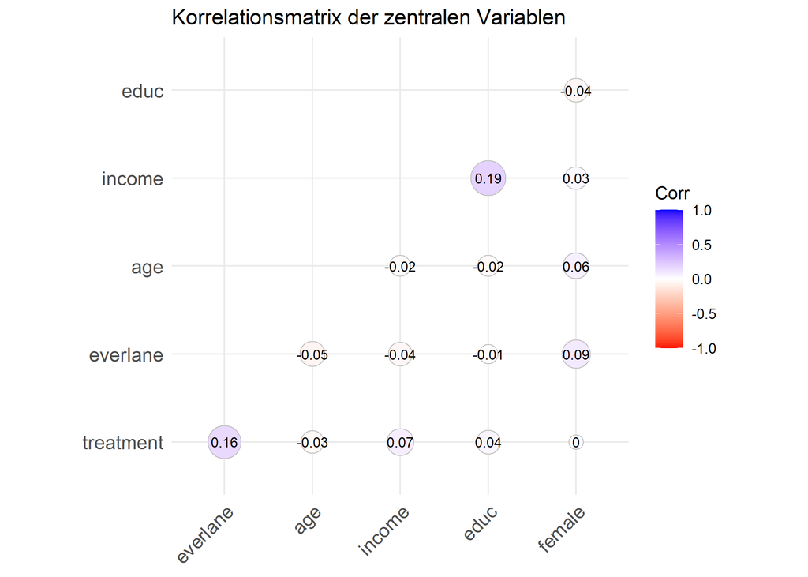

**Beschreibung**

Die dargestellte Grafik zeigt eine Korrelationsmatrix für sechs Variablen: treatment, everlane, age, income, educ und female. Die Korrelationskoeffizienten sind in einem unteren Dreieck der Matrix als farbige Kreise dargestellt, wobei die Farbintensität und Größe die Stärke der Korrelation widerspiegeln. Positive Zusammenhänge sind in Blau, negative in Rot dargestellt. Die auffälligsten Korrelationen bestehen zwischen treatment und everlane (r = 0.16) sowie zwischen income und educ (r = 0.19). Die übrigen Korrelationen liegen nahe bei null und deuten auf schwache oder keine linearen Zusammenhänge hin.

**Interpretation**

Ein positiver Zusammenhang zwischen treatment und everlane (r = 0.16) bedeutet, dass Personen, die der Treatment-Gruppe zugewiesen wurden, mit höherer Wahrscheinlichkeit die Everlane-Gutscheinkarte gewählt haben. Dies steht im Einklang mit der Hypothese, dass Kostentransparenz die Präferenz für ethischere Produkte (wie Everlane) beeinflussen könnte. Dennoch reicht eine Korrelation allein nicht aus, um einen kausalen Effekt nachzuweisen – selbst bei zufälliger Gruppenzuweisung. Korrelation misst lediglich den statistischen Zusammenhang, ohne den Einfluss dritter Variablen oder zeitlicher Abfolge zu berücksichtigen. Eine Korrelationsmatrix bietet einen kompakten Überblick über lineare Zusammenhänge zwischen mehreren Variablen gleichzeitig – anders als ein einfacher Mittelwertvergleich, der nur zwei Gruppen in einer einzigen Variable gegenüberstellt. Dadurch kann man breitere Muster erkennen und Hypothesen gezielter formulieren.

7. In Aufgabe 1 und 2 haben Sie gelesen, dass den Teilnehmern ein Angebot gemacht wurde, eine Everlane-Gutscheinkarte anzunehmen. Erzeugen Sie eine geeignete Grafik, die den durchschnittlichen Anteil der angenommenen Angebote (d.h. den Anteil, in dem die Everlane-Karte gewählt wurde) getrennt für die Treatment- und die Kontrollgruppe darstellt. Fügen Sie in der Grafik zusätzlich den Standardfehler der Mittelwerte ein. Führen Sie einen T-Test durch, um zu prüfen, ob der Unterschied im Mittelwert zwischen der Treatment- und Kontrollgruppe statistisch signifikant ist, und geben Sie das Testergebnis (den p-Wert) deutlich sichtbar in der Grafik an. Achten Sie dabei auf eine verständliche Beschriftung Ihrer Grafik sowie auf einen aussagekräftigen Titel.

Beschreiben und interpretieren Sie ihre Grafik. Gehen Sie insbesondere auf folgende Fragen ein:

- Welche Aussage lässt sich auf Basis des durchgeführten T-Tests treffen?
- Welche der in den vorherigen Aufgaben (vgl. Aufgabe 4 und 5) analysierten Faktoren könnten dazu beigetragen haben, dass ein signifikanter Unterschied im Anteil angenommener Everlane-Angebote zwischen Treatment- und Kontrollgruppe beobachtet wird?

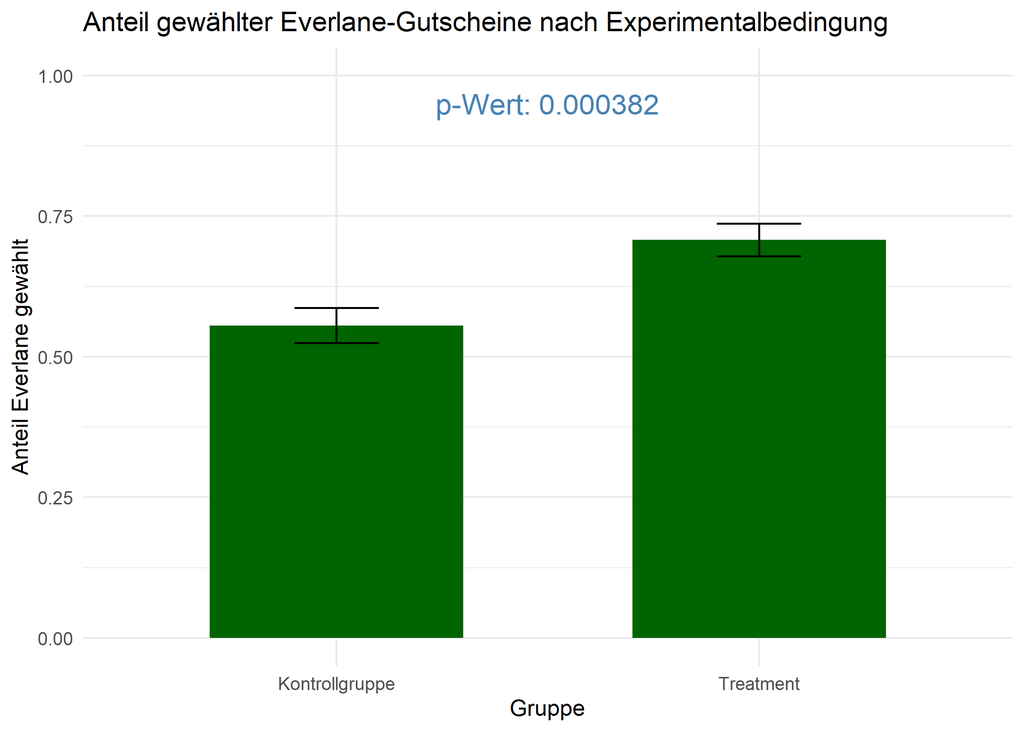

**Beschreibung**

Die Grafik zeigt den durchschnittlichen Anteil der Teilnehmer:innen, die sich für eine Everlane-Gutscheinkarte entschieden haben – getrennt nach Kontrollgruppe (ohne Kostentransparenz) und Treatmentgruppe (mit Kostentransparenz). Auf der y-Achse ist der Anteil der Everlane-Wahl dargestellt, auf der x-Achse sind die beiden Gruppen aufgeführt. Die Balken zeigen die Mittelwerte, während die Fehlerbalken den Standardfehler des Mittelwerts visualisieren. In der Kontrollgruppe lag der Anteil bei ca. 56 %, während in der Treatmentgruppe rund 71 % der Teilnehmenden die Everlane-Karte wählten. Zusätzlich ist der p-Wert aus einem t-Test direkt in der Grafik angegeben, der die Signifikanz des Unterschieds zwischen den Gruppen bewertet. Mit einem p-Wert von 0.000382 ist der Unterschied statistisch hoch signifikant.

**Analyse**

Auf Basis des durchgeführten T-Tests lässt sich schließen, dass die Wahrscheinlichkeit, dass der beobachtete Unterschied zufällig entstanden ist, extrem gering ist (p < 0.001). Das spricht für einen echten Effekt der Kostentransparenz auf die Entscheidung für Everlane. Zwar kann eine Korrelation allein keine Kausalität belegen, aber durch das experimentelle Design – konkret die zufällige Zuweisung zur Treatment- oder Kontrollgruppe – sind viele Störfaktoren kontrolliert. Dennoch könnten weitere in Aufgabe 4 und 5 untersuchte Faktoren wie Einkommen oder Bildung Einfluss haben: Zum Beispiel zeigte die Korrelationsmatrix, dass Bildung und Einkommen positiv miteinander zusammenhängen. Es ist denkbar, dass Personen mit höherer Bildung sensibler auf Transparenz reagieren, etwa weil sie Kostenangaben stärker in ihre Bewertung einbeziehen. Solche latenten Zusammenhänge könnten die Wirkung der Treatmentbedingung zusätzlich verstärken. Die Korrelationsmatrix liefert damit ergänzende Hinweise, welche Einflussfaktoren über die reine Mittelwertdifferenz hinaus bedeutsam sein könnten.

In den vorherigen Aufgaben des Projekts haben Sie sich bereits intensiv mit dem Experiment 1 auseinandergesetzt, in dem untersucht wurde, ob und wie die Offenlegung von Produktionskosten - also Kostentransparenz - das Konsumverhalten beeinflusst. Es wurde gezeigt: Wenn Konsument:innen transparent mitgeteilt wird, wie sich die Kosten eines Produkts zusammensetzen, steigt ihre Bereitschaft, bei dem entsprechend transparenten Unternehmen einzukaufen.

Diese Ergebnisse legen nahe, dass die Offenlegung sensibler Unternehmensinformationen (wie Produktionskosten) das Vertrauen der Konsument:innen in das Unternehmen stärkt und sie somit eher zu einem Kauf motiviert.

Doch was genau ist der psychologische Mechanismus hinter dieser Wirkung? Ist es tatsächlich das Vertrauen in das Unternehmen, das durch die Offenlegung sensibler Informationen gestärkt wird - und in der Folge die Kaufbereitschaft erhöht?

Um genau diese Frage zu beantworten, führen die Autoren ein weiteres Experiment durch, das den vermuteten psychologischen Vermittlungsmechanismus des Vertrauens genauer untersucht. Dabei wurde geprüft, ob Vertrauen tatsächlich als Mediator zwischen Kostentransparenz und Kaufinteresse wirkt. Hierzu wurde ein kontrolliertes Online-Experiment mit über 600 Teilnehmer:innen durchgeführt. Die Teilnehmenden wurden zufällig einer von zwei Bedingungen zugewiesen:

- In der **Kostentransparenz-Gruppe** (Treatment) wurde zusätzlich eine detaillierte Aufschlüsselung der Produktionskosten angegeben. Diese beinhaltete die einzelnen Kostenkomponenten (z.B. Kakaobutter, Verpackung, Arbeitskosten) sowie die Gesamtkosten der Schokoladentafel (vgl. Abbildung 2 im Anhang).
- In der **Kontrollgruppe** sahen die Teilnehmer die Verpackung einer fiktiven Schokoladenmarke namens „Cocoa Passion“. Diese enthielt nur die üblichen Informationen wie Zutaten, Nährwerte und eine Produktbeschreibung.

Ziel war es, zu untersuchen, ob die Offenlegung dieser sensiblen Informationen das Vertrauen der Konsument:innen in die Marke stärkt - und ob dieses Vertrauen wiederum die Kaufbereitschaft beeinflusst. In den nächsten Aufgaben werden Sie diese Studie genauer beleuchten, analysieren und evaluieren, ob sich die Hypothese empirisch bestätigen lässt.

8. Lesen Sie die Daten des zweiten Experiments (`Experiment2.csv`) in R ein. Nennen Sie den Datensatz `daten_exp2`. Benennen Sie die Variable `cost` in `treatment` um.

Untersuchen Sie, ob sich die Teilnehmer, die die Verpackung mit transparenter Kosteninformation gesehen haben, systematisch von jenen unterscheiden, die nur die Kontrollversion gesehen haben.

Erstellen Sie hierfür eine Balancing-Tabelle, in der Sie die Mittelwerte von Alter (age), Geschlecht (female), Einkommensstufe (income), Bildungsniveau (educ), Vertrauen (trust) und Kaufbereitschaft (wtb) zwischen den beiden Gruppen vergleichen, die Differenzen berechnen und mithilfe von T-Tests prüfen, ob diese Unterschiede statistisch signifikant sind. Nehmen Sie weiterhin die Anzahl an Beobachtungen in der Treatment- und in der Kontrollgruppe in ihre Tabelle mit auf.

Beschreiben und interpretieren Sie ihre Tabelle. Gehen Sie dabei insbesondere auf folgende Fragen ein:

- Was versteht man unter der Variable `wtb`?
- Was lässt sich aus der Größen der Stichprobe ableiten?
- Wo könnte es bei einer Regression (oder einem sonstigen Vergleich der Gruppen) zu Problemen kommen und was wären mögliche Auswirkungen?

*Hinweis:* Für die Beschreibung der `wtb` können Sie das bereitgestellte Readme nutzen.

Balancing-Tabelle: Vergleich zwischen Treatment- und Kontrollgruppe

| Variable | Mittelwert_Treatment | Mittelwert_Kontrollgruppe | Differenz | p_Wert |
| --- | --- | --- | --- | --- |
| age | 34.06 | 36.27 | -2.21 | 0.02 |
| female | 0.48 | 0.42 | 0.05 | 0.21 |
| income | 6.79 | 6.96 | -0.17 | 0.37 |
| educ | 3.57 | 3.51 | 0.05 | 0.44 |
| trust | 5.27 | 4.82 | 0.45 | 0.00 |
| wtb | 4.27 | 3.74 | 0.53 | 0.00 |
| Anzahl Beobachtungen | 306.00 | 308.00 | NA | NA |

**Beschreibung**

Die Tabelle zeigt die Mittelwerte von sechs Variablen (age, female, income, educ, trust, wtb) getrennt nach Treatment- und Kontrollgruppe. Für jede Variable werden folgende Werte berichtet:

Der Mittelwert in der Treatment-Gruppe,

der Mittelwert in der Kontrollgruppe,

die Differenz zwischen beiden Gruppen,

der zugehörige p-Wert aus einem t-Test.

Am Ende der Tabelle befindet sich eine zusätzliche Zeile mit der Anzahl der Beobachtungen in den beiden Gruppen:

Treatment-Gruppe: 306 Personen

Kontrollgruppe: 308 Personen

Für die Anzahl der Beobachtungen gibt es keine Differenz- oder p-Wert-Angabe, diese Felder sind mit NA belegt, da sie statistisch nicht relevant sind.

**Interpretation**

**Was versteht man unter der Variable wtb?**

wtb steht für “willingness to buy” (Kaufbereitschaft) und misst, wie wahrscheinlich es ist, dass eine Person das vorgestellte Produkt kaufen würde, auf einer Skala von 1 bis 7 (1 = überhaupt nicht wahrscheinlich, 7 = sehr wahrscheinlich).

**Was lässt sich aus der Größe der Stichprobe ableiten?**

Mit jeweils über 300 Beobachtungen pro Gruppe (306 Treatment, 308 Kontrolle) handelt es sich um eine relativ ausgewogene und ausreichend große Stichprobe. Dadurch steigt die statistische Power, also die Fähigkeit, auch kleinere Unterschiede zwischen Gruppen zuverlässig zu erkennen. Die nahezu gleiche Gruppengröße verringert zusätzlich das Risiko von Verzerrungen durch Ungleichgewicht in der Gruppenaufteilung.

**Wo könnte es bei einer Regression (oder einem Gruppenvergleich) zu Problemen kommen?**

Mögliche Auswirkungen bei einer Regression:

Die Schätzung des Treatmenteffekts könnte verzerrt sein, da er möglicherweise mit den Unterschieden in z.B. Alter oder Vertrauen konfundiert ist.

Ohne geeignete Kontrollvariablen in der Regression könnte man fälschlicherweise Effekte dem Treatment zuschreiben, die in Wahrheit auf strukturelle Unterschiede zurückgehen.

9. In ihrem Datensatz gibt es einige Beobachtungen ohne vorhandene Werte. Behalten Sie nur die Beobachtungen bei denen vollständige Werte vorliegen. Erzeugen Sie eine geeignete Grafik, welche den durchschnittlichen Anteil der ‘Kaufbereitschaft’ im zweiten Experiment für die Treatment- und Kontrollgruppe darstellt.

Die Grafik soll:

- die Mittelwerte der Kaufbereitschaft für beide Gruppen zeigen,
- die zugehörigen Standardfehler als Fehlerbalken visualisieren und
- das Ergebnis des T-Tests, der die Mittelwertdifferenz prüft, direkt in die Grafik integrieren.

Beschreiben und interpretieren Sie ihre Grafik.

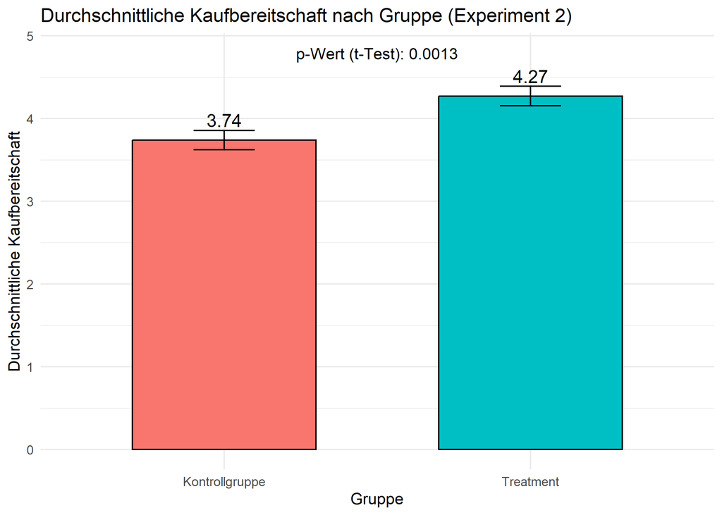

**Beschreibung**

Die vorliegende Grafik zeigt den durchschnittlichen Anteil der Kaufbereitschaft in zwei Gruppen: der Kontrollgruppe und der Treatmentgruppe. Auf der x-Achse ist die Gruppenzugehörigkeit abgetragen. Die Balken zeigen jeweils den Mittelwert der Kaufbereitschaft, ergänzt durch Fehlerbalken, die den Standardfehler des Mittelwerts darstellen. Die Mittelwerte sind überden jeweiligen Balken angegeben. Der Balken der Kontrollgruppe liegt bei etwa 3,7, der der Treatmentgruppe bei etwa 4,2. Darüber hinaus wird der p-Wert des zugehörigen T-Tests in der Grafik eingeblendet, der bei 0.0013 liegt. Die Farben der Balken unterscheiden sich, um die Gruppen visuell abzugrenzen. Insgesamt verdeutlicht die Grafik einen sichtbaren Unterschied in der durchschnittlichen Kaufbereitschaft zugunsten der Treatmentgruppe.

**Interpretation**

Der p-Wert des T-Tests (p = 0.0013) zeigt, dass der Unterschied zwischen den beiden Gruppen statistisch signifikant ist. Das bedeutet, dass die Wahrscheinlichkeit, dass dieser Unterschied zufällig entstanden ist, sehr gering ist. Daraus lässt sich schließen, dass das Treatment einen tatsächlichen Einfluss auf die Kaufbereitschaft hatte. Die höhere Bereitschaft in der Treatmentgruppe könnte durch eine gezielte Ansprache oder ein konkretes Angebot verursacht worden sein, welches in der Kontrollgruppe nicht vorlag.

Nachdem Sie nun die Differenzen in der Kaufabsicht zwischen der Treatment- und der Kontrollgruppe im zweiten Experiment überprüft und getestet haben, geht es im nächsten Schritt darum, den möglichen Mediator Vertrauen genauer zu untersuchen. Hierfür sollen Sie sich in einem ersten Schritt das Vertrauen der Personen allgemein anschauen, um einen Eindruck zu dieser wichtigen Variable zu bekommen. Dafür werden Personen anhand **hohem und niedrigem** Vertrauen und deren Kaufbereitschaft für das Produkt unterteilt.

10. Erstellen Sie eine oder mehrere geeignete Grafik(en), die den Zusammenhang zwischen Vertrauen (Trust) und der Kaufabsicht (WTB) **unabhängig** der beiden Treatment- und Kontrollgruppen darstellen. Achten Sie auf eine passende Darstellung der Informationen.

Die Grafik(en) sollen folgende Informationen enthalten:

- Unterteilen Sie ihre Daten in Personen mit `hohem` und `niedrigem` Vertrauen. Nutzen Sie für die Unterteilung den Median des Vertrauens in ihren Daten als Schwellenwert.
- Abhängig der Einstufungen in `hohes` und `niedriges` Vertrauen soll nun die durchschnittliche Kaufbereitschaft dargestellt werden. Hier soll die Grafik so dargestellt werden, dass auf der x-Achse das Vertrauensniveau (“hoch” und “niedrig”) und auf der y-Achse die entsprechende Kaufbereitschaft abgebildet wird.
- Berechnen Sie weiterhin die Mittelwerte der beiden Vertrauensgruppen und visualisieren diese in geeigneter Art und Weise in ihren Grafik(en).
- Führen Sie einen t-Test durch, um zu prüfen, ob die Mittelwertsunterschiede zwischen den beiden Vertrauensgruppen statistisch signifikant sind. Geben Sie den p-Wert in der Grafik an.

Beschreiben und interpretieren Sie ihre Grafik(en). Beantworten Sie insbesondere folgende Fragen:

- Welche Implikationen hat ein signifikanter Unterschied für die Rolle von Vertrauen auf Kaufentscheidungen?
- Wie stark unterscheidet sich die Kaufbereitschaft zwischen Personen mit hohem und niedrigem Vertrauen?
- Könnte auf Basis ihrer Darstellung Vertrauen als Mediator zwischen dem Treatment und der Kaufbereitschaft fungieren?

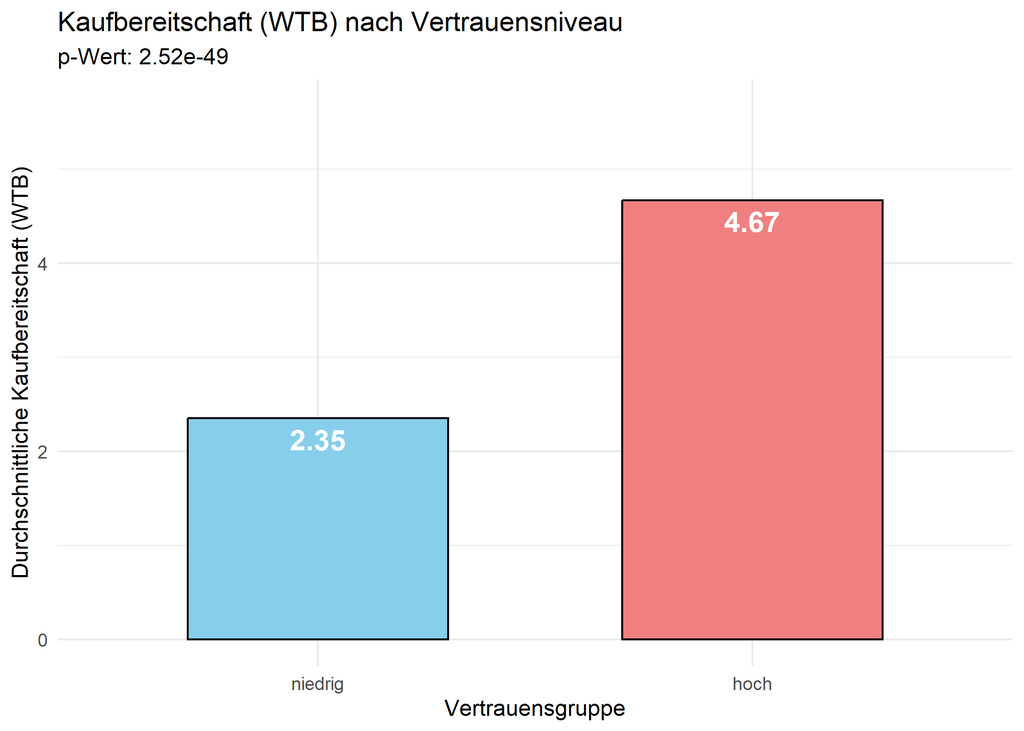

**Analyse**

Der signifikante Unterschied in der Kaufbereitschaft zeigt, dass Vertrauen eine zentrale Rolle bei Konsumentscheidungen spielt. Wenn Menschen hohes Vertrauen empfinden, etwa gegenüber einer Marke, einer Informationsquelle oder einem Anbieter, steigt ihre Bereitschaft, ein Produkt zu kaufen signifikant an. In der dargestellten Untersuchung scheint Vertrauen ein entscheidender psychologischer Faktor zu sein, der den ökonomischen Entscheidungsprozess beeinflusst. Für Unternehmen oder politische Maßnahmen bedeutet das: Wer Vertrauen schafft, erhöht potenziell auch den wirtschaftlichen Erfolg.

Der Unterschied in der Kaufbereitschaft ist nicht nur statistisch, sondern auch praktisch bedeutsam. Ein Unterschied von ca. zwei Skalenpunkten ist in der Regel als groß zu bewerten. Damit ist Vertrauen nicht bloß ein begleitender Faktor, sondern möglicherweise ein vermittelnder Mechanismus – also ein Mediator – zwischen einer vorausgehenden Maßnahme (z.B. Bildung oder gezielte Kommunikation) und der resultierenden Kaufentscheidung. Wenn z. B. höhere Bildung zu mehr Vertrauen führt, welches wiederum die Kaufbereitschaft erhöht, wäre Vertrauen ein klassischer Mediator. Diese Möglichkeit sollte in weiterführenden Analysen durch eine Mediationsanalyse überprüft werden. Insgesamt deutet die Grafik darauf hin, dass Vertrauen ein zentraler Wirkmechanismus in ökonomischen Entscheidungen sein kann – und möglicherweise auch im Zusammenhang zwischen Bildung und Einkommen eine vermittelnde Rolle spielt.

# Regressionsanalyse

Sie haben nun ihren Datensatz kennengelernt und es scheint so, als ob insbesondere Personen, welche transparente Kosten sehen, dazu neigen, das Produkt zu kaufen. Doch um ihre deskriptiven Analysen zu erhärten, wollen Sie im folgenden eine Analyse mittels Regressionen durchführen.

11. Betrachten Sie hier noch einmal das erste Experiment (`daten_exp1`). Führen Sie eine Regression durch, bei der Ihnen `everlane` als abhängige Variable dient. Als erklärende Variable nutzen Sie das `treatment`. Erstellen sie eine weitere Regression, die zusätzlich noch für die folgenden Variablen kontrolliert:
- Alter
- Bildungsstufe
- Einkommen
- Geschlecht

Stellen Sie die Regressionsergebnisse in einer Tabelle mit stargazer oder modelsummary dar!

Beschreiben und interpretieren Sie ihre Ergebnisse. Gehen Sie insbesondere auf folgende Fragen ein:

- Lässt sich der Effekt des Treatments auf die Entscheidung der Kunden kausal interpretieren?
- Ist es wichtig auf weitere Faktoren zu kontrollieren?
- Beziehen Sie sich hier auch auf die Ergebnisse aus Aufgabe 5.

|  | Everlane-Wahl ~ Treatment | Everlane-Wahl ~ Treatment + soz. Merkmale |
| --- | --- | --- |
| (Intercept) | 0.55*** | 0.69*** |
|  | (0.03) | (0.13) |
| treatment | 0.16*** | 0.15*** |
|  | (0.04) | (0.04) |
| age |  | 0.00 |
|  |  | (0.00) |
| educ |  | 0.00 |
|  |  | (0.03) |
| income |  | -0.01 |
|  |  | (0.01) |
| female |  | 0.09* |
|  |  | (0.04) |
| Num.Obs. | 509 | 505 |
| R2 | 0.028 | 0.039 |
| R2 Adj. | 0.026 | 0.030 |
| AIC | 696.8 | 690.6 |
| BIC | 709.5 | 720.1 |
| Log.Lik. | -345.416 | -338.276 |
| F | 14.376 | 4.072 |
| RMSE | 0.48 | 0.47 |

+ p < 0.1, * p < 0.05, ** p < 0.01, *** p < 0.001  
Modell 2 kontrolliert für Alter, Bildungsniveau, Einkommen und Geschlecht.

**Beschreibung**

Die Tabelle zeigt die Ergebnisse von zwei Regressionsmodellen, in denen die abhängige Variable everlane ist – also die Entscheidung der Teilnehmenden für oder gegen Everlane.

In der Spalte „Everlane-Wahl ~ Treatment“ wurde nur die Variable treatment als erklärende Variable aufgenommen.

In der Spalte „Everlane-Wahl ~ Treatment + soz. Merkmale“ wurden zusätzlich die Variablen age, educ, income und female berücksichtigt.

Für beide Modelle sind die geschätzten Koeffizienten, deren Standardfehler (in Klammern darunter), sowie Signifikanzniveaus angegeben. Besonders hervorgehoben sind:

Der Effekt der treatment-Variable (in beiden Modellen signifikant auf dem 0,001-Niveau mit drei Sternchen ***).

Die Variable female im “Everlane-Wahl ~ Treatment + soz. Merkmale” Modell zeigt einen signifikanten positiven Effekt auf dem 5%-Niveau (*).

Eine Fußnote weist darauf hin, dass im zweiten Modell für Alter, Bildungsniveau, Einkommen und Geschlecht kontrolliert wurde.

**Interpretation**

**Notwendigkeit der Kontrolle weiterer Variablen**

Auch wenn die Balancing-Tabelle aus Aufgabe 5 gezeigt hat, dass sich Treatment- und Kontrollgruppen in Alter, Geschlecht, Einkommen und Bildung nicht signifikant unterscheiden, kann es dennoch aus Effizienzgründen sinnvoll sein, diese Variablen als Kontrollvariablen aufzunehmen. Das Modell in der zweiten Spalte erlaubt präzisere Schätzungen, da es zusätzliche Varianz im Antwortverhalten erklärt.

**Bezug zu Aufgabe 5**

In Aufgabe 5 wurde durch die Balancing-Tabelle nachgewiesen, dass keine systematischen Unterschiede zwischen Treatment- und Kontrollgruppe in Bezug auf soziodemografische Merkmale bestehen. Daher ist die Randomisierung offenbar gelungen – das stärkt die Aussagekraft der regressionsbasierten Resultate. Dennoch zeigt die Regression mit Kontrolle, dass z.B. das Geschlecht (female) einen zusätzlichen signifikanten Einfluss auf die Everlane-Wahl hat. Das wäre ohne die Kontrollvariablen nicht sichtbar geworden. Dies unterstreicht die Bedeutung, auch bei randomisierten Designs zusätzliche Kovariaten zu berücksichtigen – sowohl zur Präzisionssteigerung als auch zur Identifikation weiterer relevanter Einflussfaktoren.

Während die bisherigen Analysen zeigen, dass das Treatment einen Effekt hat, stellt sich nun die Frage, warum das so ist. Nun sollten Sie im weiteren Verlauf durch vertiefende Regressionsanalysen prüfen, ob dies auf das Vertrauen der Kunden zurückzuführen ist. Dazu betrachten Sie noch einmal den Datensatz zu Experiment 2 (`daten_exp2`) und untersuchen, ob das Treatment (Kunden sehen transparente Kostenstruktur) zu einer höheren Kaufabsicht führt, weil sie das Vertrauen der Konsumenten in das Unternehmen stärkt.

12. Schauen Sie sich den Einfluss der Kostentransparenz auf die Kaufabsicht in den folgenden zwei Regressionen genauer an und zeigen Sie ihre Ergebnisse nebeneinander:

**1. Regression:** Abhängige Variable ist die Kaufabsicht; die erklärende Variable ist das Treatment.

**2. Regression:** Wie in der 1. Regression, doch kontrollieren Sie hier zusätzlich auf die Variablen Alter, Einkommensniveau, Bildungsstufe und Geschlecht.

Stellen Sie die Regressionsergebnisse in einer Tabelle mit stargazer oder modelsummary dar!

Beschreiben und interpretieren Sie ihre Ergebnisse allgemein. Gehen Sie weiterhin auch speziell auf folgende Fragen ein:

- Sollten die Kontrollvariablen in ihrer zweiten Regression den Koeffizienten des Treatments ändern? Was würden Sie erwarten und warum? Nutzen Sie hierzu die Ergebnisse aus Aufgabe 8.
  - Vergleichen Sie die Regressionskoeffizienten der Treatment-Variable in der ersten und zweiten Regression. Gibt es hier einen signifikanten Unterschied in der Größe des Effekts?
- Bringt ihnen die Regression Vorteile gegenüber einer reinen Darstellung der Mittelwerte wie in Aufgabe 9?
- Ist der Effekt des Treatments auf die Kaufabsicht ihrer Ansicht nach kausal interpretierbar?
  - Welche Voraussetzungen müssen erfüllt sein, damit man diesen Regressionskoeffizienten als kausalen Effekt interpretieren kann?
  - Überlegen Sie sich, wie sich das Ergebnis verändern würde, wenn zusätzlich Vertrauen (trust) in das Modell aufgenommen wird. Würde sich der Effekt von `treatment` verändern? Warum oder warum nicht?

|  | Kaufabsicht ~ Treatment | Kaufabsicht ~ Treatment + soz. Merkmale |
| --- | --- | --- |
| (Intercept) | 3.74*** | 3.70*** |
|  | (0.12) | (0.47) |
| treatment | 0.53** | 0.50** |
|  | (0.16) | (0.17) |
| age |  | -0.01+ |
|  |  | (0.01) |
| income |  | 0.02 |
|  |  | (0.04) |
| educ |  | 0.10 |
|  |  | (0.10) |
| female |  | 0.00 |
|  |  | (0.17) |
| Num.Obs. | 601 | 601 |
| R2 | 0.017 | 0.025 |
| R2 Adj. | 0.015 | 0.016 |
| AIC | 2555.0 | 2558.4 |
| BIC | 2568.2 | 2589.1 |
| Log.Lik. | -1274.491 | -1272.177 |
| F | 10.435 | 3.009 |
| RMSE | 2.02 | 2.01 |

+ p < 0.1, * p < 0.05, ** p < 0.01, *** p < 0.001  
Modell 2 kontrolliert für Alter, Einkommensniveau, Bildungsstufe und Geschlecht.

**Beschreibung**

Die Tabelle zeigt die Ergebnisse zweier Regressionsanalysen, in denen der Einfluss des Treatments (Kostentransparenz) auf die Kaufabsicht (wtb) untersucht wurde. Die erste Spalte (“Kaufabsicht ~ Treatment”) enthält das Ergebnis einer einfachen Regression, in der nur das Treatment als erklärende Variable verwendet wurde. Die zweite Spalte (“Kaufabsicht ~ Treatment + soz. Merkmale”) zeigt die Ergebnisse einer erweiterten Regression, in der zusätzlich für Alter (age), Einkommen (income), Bildungsniveau (educ) und Geschlecht (female) kontrolliert wurde.

Für jede Variable sind der Regressionskoeffizient sowie der Standardfehler in Klammern angegeben. Signifikanzniveaus sind durch Sternchen markiert:

*** für p < 0.001

Beide Modelle basieren auf derselben abhängigen Variable (wtb = willingness to buy).

**Interpretation**

**1. Ändern sich die Treatment-Koeffizienten zwischen den Modellen? Was wäre zu erwarten?** **Der Treatment-Koeffizient liegt bei:**

0.53 in der einfachen Regression

0.50 in der Regression mit Kontrollvariablen

→ Der Effekt bleibt stabil und nur minimal kleiner, was darauf hindeutet, dass die Aufnahme der Kontrollvariablen den Zusammenhang nicht wesentlich beeinflusst.

**2. Gibt es einen signifikanten Unterschied in der Größe des Effekts?**

Nein. Der Unterschied von 0.53 auf 0.50 ist sehr gering und nicht signifikant unterschiedlich. Beide Effekte sind statistisch signifikant (p < 0.05), was zeigt: Das Treatment hat einen positiven Effekt auf die Kaufabsicht, unabhängig von den kontrollierten Kovariaten.

**3. Bringt die Regression Vorteile gegenüber Mittelwertvergleichen (Aufgabe 9)?**

Ja. Ein reiner Mittelwertvergleich wie in Aufgabe 9 zeigt nur Unterschiede zwischen Gruppen, ohne andere mögliche Einflussfaktoren zu berücksichtigen. Die Regression erlaubt:

Kontrolle für Störvariablen (z.B. Alter, Einkommen),

Schätzung der unabhängigen Effekte einzelner Variablen,

Gerade wenn es – wie in Aufgabe 8 – signifikante Gruppenunterschiede gibt, ist eine Regression klar im Vorteil gegenüber rein deskriptiven Analysen.

**4. Ist der Effekt des Treatments kausal interpretierbar?**

Tendenziell ja, aber unter Bedingungen.

Da es sich um ein Experiment handelt, bei dem die Zuteilung zur Treatment- und Kontrollgruppe zufällig erfolgte, spricht das für eine mögliche kausale Interpretation.

Voraussetzungen für kausale Interpretation:

Randomisierung (gegeben),

keine systematischen Unterschiede außer dem Treatment (in Aufgabe 8 nur teilweise erfüllt),

keine unbeobachteten Störfaktoren, die mit Treatment und Kaufabsicht zusammenhängen,

kein post-treatment bias (z.B. keine Variablen kontrollieren, die vom Treatment beeinflusst sein könnten – wie Vertrauen!).

**5. Was passiert, wenn trust ins Modell aufgenommen wird?**

Wird trust (Vertrauen) ins Modell aufgenommen, ändert sich der Effekt von treatment wahrscheinlich deutlich.

Warum?

Weil trust vermittelt, wie treatment auf wtb wirkt. Wenn Transparenz Vertrauen stärkt und Vertrauen wiederum Kaufabsicht erhöht, dann ist trust ein Mediator. Wird ein Mediator in die Regression aufgenommen, wird ein Teil des ursprünglichen Effekts des Treatments „herausgerechnet“, und der Koeffizient von treatment sinkt oder verliert Signifikanz.

Das bedeutet:

Ein Rückgang des treatment-Effekts nach Aufnahme von trust wäre ein Indiz dafür, dass Vertrauen ein zentraler Wirkmechanismus ist.

Sie haben nun gesehen, dass es auch hier einen direkten Effekt des Treatments (transparente Kostenstrukur) auf die Kaufabsicht gibt. Doch um die dahinter liegenden Mechanismen zu verstehen, müssen Sie tiefer in psychologische Prozesse eintauchen. Experiment 2 zeigt dafür ein entsprechendes Design, um zu testen, ob Vertrauen als vermittelnder Mechanismus eine Rolle spielt. Im nächsten Schritt analysieren Sie nun selbst diese Beziehung mit theoretischen Modellen und Regressionsmethoden, um ein Gefühl dafür zu bekommen, wie sich direkte und indirekte Effekte voneinander unterscheiden.

13. Bevor Sie im nächsten Schritt ein konkretes DAG zu einem psychologischen Mediationsmechanismus erstellen, machen Sie sich zunächst mit den theoretischen Grundlagen von Directed Acyclic Graphs (DAGs) vertraut. DAGs (gerichtete azyklische Graphen) sind ein nützliches Werkzeug in der Kausalanalyse.

Beantworten Sie folgende theoretische Fragen zu DAGs:

- Wofür werden DAGs in der empirischen Forschung verwendet?
- Nennen und beschreiben Sie zwei zentrale Knotentypen in einem DAG: Confounder und Mediator.
- Worin besteht der zentrale Unterschied, ob Vertrauen als Kontrollvariable (Confounder) oder als Mediator behandelt wird - und warum ist Letzteres entscheidend für das Verständnis psychologischer Prozesse im vorliegenden Experiment?

**Wofür werden DAGs in der empirischen Forschung verwendet?**

Directed Acyclic Graphs (DAGs) sind grafische Modelle, mit denen kausale Beziehungen zwischen Variablen dargestellt und analysiert werden. Sie bestehen aus Knoten (Variablen) und gerichteten Kanten (Pfeilen), die die Richtung des Einflusses anzeigen. „Azyklisch“ bedeutet, dass kein Kreis entsteht – man kann also nicht von einem Knoten über andere wieder zu diesem zurückkehren.

DAGs werden genutzt, um:

Hypothesen über kausale Strukturen explizit zu machen,

Konfundierung, Mediator-Beziehungen und Scheinkorrelationen sichtbar zu machen,

zu entscheiden, welche Variablen kontrolliert werden müssen, um unverzerrte kausale Effekte zu schätzen (Backdoor-Kriterium),

Identifikationsstrategien in empirischen Analysen zu entwickeln.

**Zentrale Knotentypen: Confounder und Mediator**

1. Confounder (Störfaktor / Drittvariable)

Ein Confounder ist eine Variable, die sowohl die unabhängige als auch die abhängige Variable beeinflusst. Wenn man nicht für Confounder kontrolliert, entsteht ein verzerrter Eindruck vom Zusammenhang zwischen Ursache und Wirkung.

Beispiel im Kontext: Wenn Alter sowohl beeinflusst, ob jemand dem Treatment zugeordnet wird (z.B. durch Zufall nicht gleich verteilt) und wie stark die Kaufabsicht ist, dann ist Alter ein Confounder.

Ziel: Confounder müssen kontrolliert werden, um den wahren kausalen Effekt des Treatments zu isolieren.

2. Mediator (vermittelnde Variable)

Ein Mediator liegt auf dem kausalen Pfad zwischen Ursache und Wirkung. Die unabhängige Variable beeinflusst den Mediator, der wiederum die abhängige Variable beeinflusst.

Beispiel im Kontext: Das Treatment (Transparenz) erhöht Vertrauen, und das Vertrauen erhöht die Kaufabsicht. Dann ist Vertrauen ein Mediator.

Ziel: Mediatoren zeigen wie ein Effekt zustande kommt – sie sind also entscheidend für das Verständnis des Wirkmechanismus.

**Unterschied: Vertrauen als Confounder vs. Mediator**

Confounder

Bedeutung: Vertrauen beeinflusst sowohl Treatment-Zuweisung als auch Kaufabsicht.

Konsequenz für Modellierung: Vertrauen muss kontrolliert werden, um Verzerrung zu vermeiden.

Mediator

Bedeutung: Vertrauen entsteht durch das Treatment und beeinflusst dann die Kaufabsicht.

Konsequenz für Modellierung: Vertrauen sollte nicht kontrolliert, sondern modelliert werden, um den indirekten Effekt sichtbar zu machen.

**Warum ist Vertrauen als Mediator entscheidend im vorliegenden Experiment?**

Im Experiment wurde das Treatment gezielt eingesetzt, um psychologische Prozesse wie Vertrauen zu beeinflussen. Das Ziel ist zu verstehen:

Ob Transparenz über Vertrauen wirkt, also: Hat Transparenz nur dann Einfluss auf Kaufabsicht, wenn sie Vertrauen erzeugt?

Dies erfordert eine Mediationsanalyse, bei der Vertrauen nicht als Störfaktor, sondern als Vermittler betrachtet wird.

Würde man Vertrauen als Kontrollvariable behandeln, würde man genau den Mechanismus aus dem Modell herausnehmen, den man eigentlich verstehen will. Das Ergebnis wäre ein unterschätzter oder sogar falsch eingeschätzter Treatmenteffekt.

14. Nutzen Sie nun das Directed Acyclic Graph (DAG), um die Beziehungen zwischen den Variablen Treatment (T), Vertrauen (V) und Kaufbereitschaft (K) zu analysieren und den vermuteten Mediationsmechanismus zu untersuchen.

Beschreiben und interpretieren Sie ihr DAG und die Beziehungen zwischen den Variablen. Gehen Sie insbesondere auf folgende Fragen und Aspekte ein:

- Begründen und erklären Sie die Struktur und den Aufbau ihres DAGs.
- Welche Annahmen müssen getroffen werden, damit Vertrauen tatsächlich als Mediator interpretiert werden kann?
- Welche Verzerrungen oder Störfaktoren könnten den Mediator-Effekt von Vertrauen beeinflussen? Wie könnte dies die Ergebnisse verzerren?

*Hinweis 1:* Für die Erstellung des DAGs können Sie das Paket `dagify` verwenden. Als Grundlage und Hilfsmittel können Sie die Vorlesungsfolien nutzen.

*Hinweis 2:* Eine direkte Visualisierung des DAGs in `R` ist schön, aber keine Pflicht. Sie können das DAG auch in Word/PowerPoint zeichnen und ihre Grafik mittels `include_graphics()` einfügen.

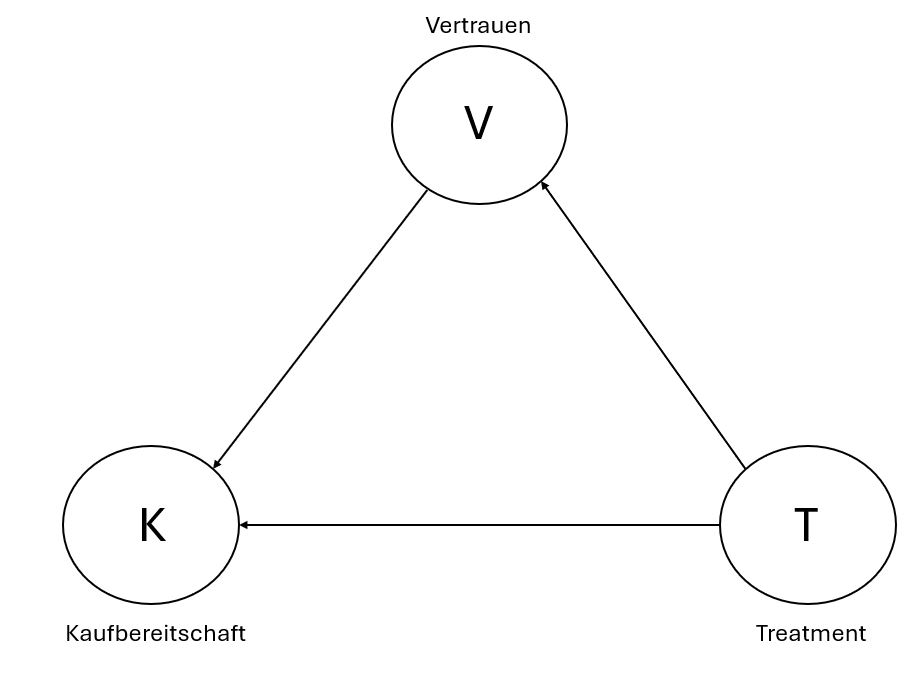

**Beschreibung**

Das dargestellte Directed Acyclic Graph (DAG) zeigt drei Variablen:

T steht für Treatment,

V steht für Vertrauen und

K steht für Kaufbereitschaft.

Es gibt gerichtete Pfeile von T → V, T → K und V → K. Das bedeutet, dass angenommen wird, dass das Treatment sowohl einen direkten Einfluss auf das Vertrauen als auch auf die Kaufbereitschaft hat. Zusätzlich beeinflusst Vertrauen wiederum die Kaufbereitschaft. Es handelt sich also um ein klassisches Mediationsmodell.

**Interpretation**

**Struktur & Begründung**

Die Struktur des DAGs folgt einem theoretischen Modell aus der Konsumentenpsychologie: Wenn Kunden transparente Informationen über Preise erhalten (Treatment), steigt ihr Vertrauen in das Unternehmen. Dieses Vertrauen wiederum erhöht die Bereitschaft, ein Produkt zu kaufen. Gleichzeitig wird ein direkter Effekt des Treatments auf die Kaufbereitschaft nicht ausgeschlossen, z.B. durch wahrgenommene Fairness oder Kompetenz.

**Notwendige Annahmen zur Mediator-Interpretation**

Damit Vertrauen als echter Mediator interpretiert werden kann, müssen folgende Annahmen erfüllt sein:

Kausalität: Das Treatment beeinflusst tatsächlich Vertrauen, und Vertrauen beeinflusst tatsächlich Kaufbereitschaft.

Keine unbeobachteten Confounder zwischen:

Treatment und Vertrauen

Vertrauen und Kaufbereitschaft

Kein umgekehrter Kausalzusammenhang (z.B. Kaufbereitschaft beeinflusst Vertrauen).

Temporalität: Das Treatment muss vor dem Vertrauen und dieses wiederum vor der Kaufbereitschaft gemessen bzw. wirksam geworden sein

**Potenzielle Verzerrungen / Störfaktoren**

Verzerrungen können auftreten, wenn nicht beobachtete Drittvariablen sowohl Vertrauen als auch Kaufbereitschaft beeinflussen, z.B.:

Persönlichkeitsmerkmale (z.B. generelles Misstrauen oder Konsumfreude),

Vorerfahrungen mit dem Unternehmen,

Einstellungen gegenüber Preistransparenz.

Wenn solche Variablen nicht kontrolliert werden, könnten die beobachteten Effekte fälschlich als Wirkung des Treatments interpretiert werden – obwohl sie durch einen gemeinsamen Einflussfaktor erklärt werden könnten.

Zudem könnte es zu einer sogenannten Post-Treatment-Bias kommen, wenn man Vertrauen als Kontrollvariable behandelt, obwohl es ein Mediator ist. In diesem Fall würde man den indirekten Effekt über Vertrauen „herausrechnen“ und den wahren Gesamtzusammenhang unterschätzen.

15. Führen Sie nun eine Regression durch, bei der Ihnen `trust` (Vertrauen) als abhängige Variable dient. Weiterhin soll ihnen `treatment` als erklärende Variable dienen. Erstellen sie eine weitere Regression, die zusätzlich noch für die folgenden Variablen kontrolliert: Alter, Einkommensniveau, Bildungsstufe und ob die Personen weiblich sind.

Stellen Sie die Regressionsergebnisse in einer Tabelle mit stargazer oder modelsummary dar!

Beschreiben und interpretieren Sie ihre Ergebnisse. Gehen Sie bei der Interpretation der Ergebnisse insbesondere auf folgende Fragen ein:

- Macht es ihrer Ansicht nach Sinn auf die zusätzlichen Variablen in Regression 2 zu kontrollieren? Worauf müssen Sie besonders achten?
- Was bedeutet ein signifikanter positiver Koeffizient für treatment in Bezug auf Vertrauen?
- Warum ist dieser Pfad (Treatment ➝ Trust) notwendig, damit eine Mediation überhaupt möglich ist?
- Überlegen Sie, ob andere Faktoren, die Sie möglicherweise nicht berücksichtigt haben, diesen Zusammenhang ebenfalls erklären könnten.

|  | Vertrauen ~ Treatment | Vertrauen ~ Treatment + Kontrolle |
| --- | --- | --- |
| (Intercept) | 4.821*** | 4.716*** |
|  | (0.079) | (0.320) |
| treatment | 0.473*** | 0.454*** |
|  | (0.112) | (0.113) |
| age |  | -0.001 |
|  |  | (0.005) |
| income |  | -0.021 |
|  |  | (0.024) |
| educ |  | 0.058 |
|  |  | (0.067) |
| female |  | 0.179 |
|  |  | (0.114) |
| Num.Obs. | 601 | 601 |
| R2 | 0.029 | 0.035 |
| R2 Adj. | 0.027 | 0.027 |
| AIC | 2091.3 | 2095.6 |
| BIC | 2104.5 | 2126.4 |
| Log.Lik. | -1042.644 | -1040.795 |
| F | 17.791 | 4.291 |
| RMSE | 1.37 | 1.37 |

+ p < 0.1, * p < 0.05, ** p < 0.01, *** p < 0.001

**Beschreibung**

Die Tabelle zeigt die Ergebnisse zweier Regressionsmodelle, bei denen die abhängige Variable das Vertrauen (trust) ist. In beiden Modellen ist die Hauptvariable von Interesse das Treatment, welches angibt, ob Teilnehmende eine transparente Kostenstruktur gesehen haben.

Modell 1 („Vertrauen ~ Treatment“)

Das Intercept beträgt 4.821 mit einem Standardfehler von 0.079.

Der Koeffizient für treatment liegt bei 0.473 mit einem Standardfehler von 0.112, und er ist statistisch signifikant (***).

Modell 2 („Vertrauen ~ Treatment + soz. Merkmale“)

Das Intercept beträgt 4.716 mit einem Standardfehler von 0.320.

Der Koeffizient für treatment liegt bei 0.454 (Standardfehler 0.113) und ist ebenfalls hoch signifikant (***).

Weitere erklärende Variablen: age (-0.001), income (-0.021), educ (0.058), female (0.179), jeweils mit ihren Standardfehlern.

Insgesamt wurden hier 601 Beobachtungen einbezogen.

**Interpretation**

Die Regressionsanalysen zeigen, dass das Treatment – also die transparente Kostenstruktur – einen signifikant positiven Einfluss auf das Vertrauen (trust) der Teilnehmenden hat. Das bedeutet: Personen, die das Treatment erhalten haben, berichten im Durchschnitt ein höheres Vertrauen in das Unternehmen.

Sinn der Kontrollvariablen in Modell 2: Es ist grundsätzlich sinnvoll, für Variablen wie Alter, Einkommen, Bildung und Geschlecht zu kontrollieren, insbesondere wenn diese theoretisch oder empirisch mit Vertrauen korreliert sein könnten. Sie helfen, alternative Erklärungen auszuschließen. Wichtig ist jedoch, dass diese Kontrollvariablen nicht selbst durch das Treatment beeinflusst werden (also keine „Post-Treatment“-Variablen sind) – sonst könnten sie den Effekt des Treatments verzerren.

Bedeutung des positiven Treatment-Koeffizienten: Der signifikant positive Koeffizient für treatment zeigt, dass das Treatment tatsächlich mit einem höheren Vertrauen assoziiert ist. Dieser Pfad ist essentiell für eine Mediation, denn Vertrauen kann nur ein Mediator sein, wenn es erstens vom Treatment beeinflusst wird (T ➝ V) und zweitens seinerseits die Kaufabsicht beeinflusst (V ➝ K).

Notwendigkeit dieses Pfads für Mediation: Ohne einen kausalen Pfad von Treatment zu Vertrauen kann Vertrauen nicht als vermittelnde Variable (Mediator) fungieren. Dieser erste Schritt der Mediation – dass das Treatment das Vertrauen beeinflusst – wird hier durch die Regression empirisch gestützt.

Mögliche unbeobachtete Störfaktoren: Denkbar ist, dass es weitere unbeobachtete Variablen gibt, die sowohl das Vertrauen als auch die Wahrnehmung des Treatments beeinflussen könnten, z.B.:

generelles Misstrauen gegenüber Werbung,

persönliche Erfahrungen mit ähnlichen Unternehmen,

psychologische Dispositionen wie Skepsis oder Vertrauensneigung.

Diese könnten eine Scheinkorrelation zwischen Treatment und Vertrauen erzeugen, wenn sie nicht kontrolliert werden. Eine randomisierte Zuteilung des Treatments, wie in diesem Experiment geschehen, reduziert solche Verzerrungen.

16. Nachdem Sie nun den Effekt des Treatments auf das Vertrauen geschätzt und ausgewertet haben, sollen Sie nun testen, ob das Vertrauen als Mediator zwischen Treatment und Kaufabsicht wirkt.

Führen Sie eine Regression durch, bei der Ihnen die Kaufbereitschaft als abhängige Variable dient. Weiterhin sollen die erklärende Variablen nun `treatment`, sowie das Vertrauen (`trust`) umfassen. Erstellen sie eine weitere Regression, die zusätzlich noch auf Alter, Einkommensniveau, Bildungsstufe und ob die Personen weiblich sind, kontrolliert.

Stellen Sie die Regressionsergebnisse passend in einer Tabelle dar!

Beschreiben und interpretieren Sie ihre Ergebnisse. Gehen Sie bei der Interpretation der Ergebnisse insbesondere auf folgende Fragen ein:

- Was könnten Ihrer Ansicht nach Gründe sein, dass `treatment` jetzt nicht mehr signifkant ist? Woran könnt das im Detail liegen?
- Warum ist es wichtig, `trust` und `treatment` gemeinsam in einem Modell zu betrachten?
- Warum könnte `trust` eine “notwendige Bedingung” sein, damit Transparenz der Kostenstruktur zu höherer Kaufbereitschaft führt?

|  | Kaufabsicht ~ Treatment + Vertrauen | Kaufabsicht ~ Treatment + Vertrauen + Kontrolle |
| --- | --- | --- |
| (Intercept) | -0.178 | -0.155 |
|  | (0.260) | (0.457) |
| treatment | 0.148 | 0.129 |
|  | (0.140) | (0.140) |
| trust | 0.813*** | 0.818*** |
|  | (0.050) | (0.050) |
| age |  | -0.013* |
|  |  | (0.006) |
| income |  | 0.041 |
|  |  | (0.030) |
| educ |  | 0.055 |
|  |  | (0.082) |
| female |  | -0.148 |
|  |  | (0.140) |
| Num.Obs. | 601 | 601 |
| R2 | 0.317 | 0.327 |
| R2 Adj. | 0.315 | 0.320 |
| AIC | 2337.9 | 2337.7 |
| BIC | 2355.5 | 2372.9 |
| Log.Lik. | -1164.952 | -1160.835 |
| F | 139.008 | 48.027 |
| RMSE | 1.68 | 1.67 |

+ p < 0.1, * p < 0.05, ** p < 0.01, *** p < 0.001

**Beschreibung**

Die Tabelle zeigt zwei Regressionsmodelle zur Vorhersage der Kaufbereitschaft (`wtb`) im zweiten Experiment. In beiden Modellen ist `trust` (Vertrauen) eine zentrale erklärende Variable. Im ersten Modell („Kaufabsicht ~ Treatment + Vertrauen“) sind lediglich `treatment` (Kostentransparenz) und `trust` als erklärende Variablen enthalten. Im zweiten Modell („Kaufabsicht ~ Treatment + Vertrauen + soz. Merkmale“) werden zusätzlich Alter (`age`), Einkommen (`income`), Bildungsniveau (`educ`) und Geschlecht (`female`) berücksichtigt.

In beiden Modellen bleibt der Einfluss von `trust` hoch signifikant und positiv, während `treatment` nicht mehr signifikant ist. Das deutet darauf hin, dass Vertrauen einen starken Einfluss auf die Kaufbereitschaft hat – unabhängig von anderen sozioökonomischen Merkmalen. Der Koeffizient von `treatment` sinkt von einem signifikanten Wert in vorherigen Modellen auf einen nicht signifikanten Wert, sobald `trust` in das Modell aufgenommen wird.

**Interpretation**

Ein Grund dafür, dass `treatment` im Modell mit `trust` nicht mehr signifikant ist, liegt darin, dass `trust` selbst den kausalen Pfad zwischen `treatment` und `wtb` vermittelt. Das bedeutet: Der Effekt des `treatment` läuft über `trust`. Sobald dieser Mediator kontrolliert wird, bleibt für den direkten Einfluss des `treatment` kein statistisch signifikanter Rest mehr übrig. Dieses klassische Mediationsmuster bestätigt die Hypothese aus der Theorie von Mohan et al. (2020), wonach Vertrauen die zentrale psychologische Größe ist, durch die Kostentransparenz auf das Verhalten wirkt.

`trust` und `treatment` gemeinsam im Modell zu betrachten, ist daher entscheidend, um zwischen direktem und indirektem Effekt zu unterscheiden. Ohne Vertrauen könnte Transparenz als bloße Information nicht wirken – erst die Wahrnehmung dieser Offenheit als „ehrlich“ oder „kundenorientiert“ aktiviert Vertrauen. Dieses wiederum beeinflusst die Entscheidung zu kaufen, wie die signifikanten Ergebnisse zeigen.

Dass `trust` eine notwendige Bedingung ist, ergibt sich auch aus der Logik der Vertrauenspsychologie: Ohne ein Mindestmaß an Vertrauen bleibt auch transparente Kommunikation wirkungslos. Vertrauen wirkt also nicht als additive Verstärkung, sondern als Katalysator. Fehlt es, kann auch Transparenz keine Wirkung entfalten. Insofern zeigen die Regressionsresultate, dass `trust` kein optionaler Zusatz, sondern eine psychologische Voraussetzung für den Erfolg von transparenter Unternehmenskommunikation ist.

In den vorangegangenen Modellen wurde untersucht, ob das Treatment (Kostentransparenz) das Vertrauen in das Unternehmen beeinflusst und ob Vertrauen wiederum mit der Kaufabsicht zusammenhängt.

17. Bewerten Sie das experimentelle Design der Studie 2. Gehen Sie dabei auch darauf ein, inwiefern Ihre Ergebnisse aus Aufgabe 13 bis 16 das theoretische Verständnis von Vertrauensbildung in der Konsumentenpsychologie bestätigt oder infrage stellt. Welche Stärken und Schwächen sehen Sie bezüglich der internen Validität und der Kausalitätsaussagen? Diskutieren Sie zudem kurz, inwiefern die Ergebnisse auf andere Bevölkerungsgruppen oder kulturelle Kontexte übertragbar sind.

*Hinweis:* Informationen zum Verständnis der Vertrauensbildung in der Konsumentenpsychologie können Sie [in dem folgenden Artikel](https://www.shs-conferences.org/articles/shsconf/pdf/2021/26/shsconf_appsconf2021_03019.pdf) auf Seite 2 bis 5 nachlesen.

In Studie 2 wurde untersucht, ob Kostentransparenz über den Aufbau von Vertrauen die Kaufbereitschaft der Konsument:innen steigert. Die Teilnehmenden wurden zufällig einer von zwei Gruppen zugewiesen (klassisches Randomisierungsdesign), was eine hohe interne Validität gewährleistet. Dadurch lässt sich ein kausaler Effekt des Treatments – also der transparenten Kostenaufstellung – auf das Vertrauen begründet ableiten.

Die Ergebnisse der Aufgaben 13 bis 16 zeigen, dass Transparenz das Vertrauen signifikant erhöht und dieses Vertrauen wiederum stark mit der Kaufbereitschaft zusammenhängt. Sobald Vertrauen als erklärende Variable in das Regressionsmodell aufgenommen wurde, reduzierte sich der direkte Effekt der Kostentransparenz deutlich. Das spricht für eine Mediation – also dafür, dass Vertrauen ein vermittelnder Mechanismus zwischen Transparenz und Kaufabsicht ist.

Diese Befunde stützen theoretische Modelle der Vertrauensbildung im Marketing. So beschreiben Zsigmondová et al. (2021) Vertrauen als eine multidimensionale Verhaltenshaltung, die auf Wahrnehmungen von Kompetenz, Integrität und Wohlwollen basiert – insbesondere in Situationen mit Informationsasymmetrie. Im konkreten Fall signalisiert die transparente Kostenaufstellung Offenheit und Fairness seitens des Unternehmens, was laut Theorie eine positive Erwartungshaltung aufbaut und Vertrauen fördert.

**Stärken des Designs:**

Die Randomisierung ermöglicht kausale Aussagen zum Effekt des Treatments auf Vertrauen.

Der Mediationsansatz wurde theoretisch fundiert und empirisch getestet.

Das Studiendesign ist einfach, aber effektiv, um psychologische Wirkmechanismen wie Vertrauen zu analysieren.

Die Studie ist gut anschlussfähig an bestehende Literatur – z.B. an Garbarino & Lee (2003) zur Rolle von Wohlwollen und Offenheit im Vertrauensaufbau.

**Schwächen und Einschränkungen:**

Kausalität ist nur teilweise gegeben: Zwar lässt sich für den Zusammenhang zwischen Treatment und Vertrauen ein kausaler Effekt annehmen. Die Verbindung zwischen Vertrauen und Kaufabsicht bleibt jedoch rein korrelativ, da Vertrauen nicht experimentell manipuliert wurde.

Selbstbericht als Messmethode: Vertrauen wurde per Fragebogen erfasst – das birgt Risiken sozialer Erwünschtheit oder subjektiver Verzerrung.

Fehlende Kontrolle weiterer Mechanismen: Andere psychologische Faktoren wie Fairnesswahrnehmung, wahrgenommene Kompetenz oder Sympathie könnten ebenfalls als Mediatoren infrage kommen, wurden jedoch nicht berücksichtigt.

**Kulturelle Übertragbarkeit:**

Die Generalisierbarkeit der Ergebnisse ist eingeschränkt. Wie Zsigmondová et al. (2021) hervorheben, hängt der Aufbau von Vertrauen stark von kulturellen Faktoren ab. In kollektivistisch geprägten Gesellschaften entsteht Vertrauen häufig durch persönliche Beziehungen oder langfristige Interaktion, während es in individualistischen Kulturen eher über abstrakte Informationen und systemisches Vertrauen (z. B. institutionelle Offenheit) aufgebaut wird. Die Wirkung einer rein informativen Maßnahme wie einer Kostenaufstellung könnte daher in anderen Kulturkreisen deutlich schwächer ausfallen – insbesondere, wenn Vertrauen dort stärker auf persönlicher Nähe oder sozialer Verpflichtung basiert.

**Fazit:**

Das experimentelle Design von Studie 2 ist methodisch solide und bietet gute Voraussetzungen zur Analyse psychologischer Wirkmechanismen wie Vertrauen. Die Ergebnisse liefern empirische Hinweise darauf, dass Transparenz über Vertrauen die Kaufbereitschaft beeinflusst – und unterstützen somit zentrale theoretische Annahmen aus der Vertrauensforschung. Kulturelle und methodische Einschränkungen sollten jedoch bei der Interpretation und möglichen Anwendung der Ergebnisse berücksichtigt werden.

# Zusatzaufgabe

Zu Beginn des Projektes hatten wir erwähnt, dass die Experimente, welche im Projekt durchgeführt wurden, auf Grund eines Missgeschicks in der Online-Darstellung von unterschiedlichen Produkten zustande kam. Hier wurden von einem privat geführten Online-Händler Geldbörsen in fünf Farbvarianten angeboten, wobei beabsichtigt war, allen Farben eine einheitliche Kostentransparenz-Infografik zuzuordnen. Aufgrund eines Versehens wurde die Infografik jedoch nur bei drei Farben implementiert. Dieses zufällige Ereignis führte zu einer klaren Trennung zwischen den Produkten mit dieser und ohne diese Infografik. Das dadurch entstandene natürliche Experiment sollen Sie sich in der Zusatzaufgabe näher anschauen.

18. Lesen Sie sich den nachfolgenden Text zum Aufbau des natürlichen Experiments innerhalb dieses Papers durch und beantworten anschließend nachfolgende Fragen:

On December 2, 2013, a privately held online retailer launched a holiday gift shop with a single email to its mailing list, promoting a leather wallet offered in five colors (burgundy, black, grey, bone, and tan) and priced at $115.00. Later, at the end of January, to boost post-holiday sales, the retailer decided to add a cost transparency infographic to the online product detail pages for each of the wallet’s five color combinations. The retailer’s intention was to use the same infographic for all wallets since they differed only in color.

However, due to an inadvertent mistake, the infographic was not introduced for two of the wallet colors (bone and tan). Consequently, the cost transparency information was implemented for only three of the five wallet colors (burgundy, black, and grey) over a period of five weeks. This error created a natural experiment, enabling us to test the impact of cost transparency on wallet sales.

Therefore we have the following procedure:

- Operationalization of Cost Transparency: The infographic presented the total cost to produce the wallet, breaking it down into its specific components, namely: leather (14.68 US-Dollar), construction (38.56 US-Dollar), duties (4.26 US-Dollar), and transportation (1.00 US-Dollar). In addition, it included benchmark information indicating that the wallet had a 1.9x markup, in contrast to a 6x markup charged by a competitor. Because wallet colors serve as the basis for treatment assignment, the natural experiment compares “cost transparent” wallets (burgundy, black, and grey) to “non-transparent” wallets (bone and tan).
- Identification Strategy: We use a difference-in-differences approach to compare the daily sales between the treatment (cost transparency) and control (no cost transparency) groups before versus after the introduction of the infographic. By doing so, the design isolates the causal effect of cost transparency on the daily count of wallets sold for each color.
- Control Variables: Given that the cost transparency treatment was implemented by wallet color, and with only five available colors, it was necessary to control for potential confounders. For instance, we include a proxy for time-varying color popularity - the number of page views each wallet color received - and a proxy for time-varying inventory levels.

Beantworten Sie nun die folgenden Fragen in Bezug auf den vorherigen Text:

- Wie ist das natürliche Experiment aufgebaut, und warum wird es als solches klassifiziert?
- Welche Rolle spielt das zufällige Versäumnis, die Infografik bei zwei der fünf Farbvarianten einzuführen, in der Experimentstruktur?
- Warum ist es notwendig, Variablen wie Seitenaufrufe und Lagerbestandsproxies in die Analyse einzubeziehen?
- Welche potenziellen Verzerrungen könnten auftreten, wenn diese Kontrollvariablen nicht berücksichtigt werden?

**Wie ist das natürliche Experiment aufgebaut, und warum wird es als solches klassifiziert?**

Das natürliche Experiment entstand unbeabsichtigt durch einen Fehler bei der Produktdarstellung im Online-Shop: Die Infografik zur Kostentransparenz wurde nur bei drei von fünf Farbvarianten der Geldbörse angezeigt. Die Zuweisung des Treatments (Infografik) erfolgte nicht absichtlich oder systematisch, sondern zufällig durch ein Versehen.

Diese Art der Zuweisung erfüllt zentrale Kriterien eines natürlichen Experiments:

Es gibt eine Threatmentgruppe (Farben mit Infografik) und eine Kontrollgruppe (Farben ohne Infografik),

Die Zuweisung zum Treatment ist exogen, also unabhängig von den Merkmalen der Käufer oder Produkte selbst,

Dadurch lassen sich kausale Effekte untersuchen – hier: der Effekt von Kostentransparenz auf Verkaufszahlen.

**Welche Rolle spielt das zufällige Versäumnis, die Infografik bei zwei der fünf Farbvarianten einzuführen, in der Experimentstruktur?**

Dieses Versäumnis ist der zentrale Auslöser des Experiments und sorgt für die nötige Exogenität in der Treatment-Zuweisung. Es bedeutet:

Die Farbvarianten wurden nicht gezielt mit oder ohne Infografik ausgestattet sondern durch ein versehen wurden nur manchen Farbvarianten Infografiken beigefügt,

Dies reduziert Selektionseffekte und Bias und ermöglicht eine vergleichbare Ausgangslage zwischen den Gruppen.

Dadurch kann man den Effekt der Transparenz-Infografik besser als kausal interpretieren, was bei vielen Beobachtungsstudien nicht möglich ist.

**Warum ist es notwendig, Variablen wie Seitenaufrufe und Lagerbestandsproxies in die Analyse einzubeziehen?**

Seitenaufrufe und Lagerbestand sind potenzielle zeitlich variierende Störgrößen, die die Verkaufszahlen unabhängig vom Treatment beeinflussen können:

Ein bestimmtes Modell (z.B. in einer beliebten Farbe) könnte mehr Seitenbesuche haben und deshalb besser verkauft werden,

Ist ein Produkt nicht lieferbar oder knapp im Lager, sinken die Verkäufe unabhängig von der Infografik.

Diese Variablen könnten also zu Scheinkorrelationen führen, wenn sie nicht berücksichtigt werden. Ihre Einbeziehung hilft:

Trends und Nachfrageeffekte über die Zeit zu kontrollieren,

Den reinen Effekt der Infografik isoliert zu schätzen.

**Welche potenziellen Verzerrungen könnten auftreten, wenn diese Kontrollvariablen nicht berücksichtigt werden?**

Wenn man diese Kontrollvariablen nicht berücksichtigt, besteht die Gefahr von verzerrten Schätzungen:

Beliebtheitseffekte: Wenn z.B. die beliebteren Farben zufällig die Infografik erhalten haben, könnte der Effekt von Kostentransparenz überschätzt werden.

Lagerengpässe: Wenn ein Modell ohne Infografik nicht mehr verfügbar ist, erscheinen die Verkäufe dort künstlich niedriger – was fälschlich als Effekt der fehlenden Transparenz interpretiert werden könnte.

Ohne diese Kontrollen würde man also Verkaufsunterschiede fälschlich dem Treatment zuschreiben, obwohl sie eigentlich durch andere (nicht berücksichtigte) Faktoren verursacht wurden.

19. Lesen Sie weiterhin das Kapitel [“Difference-in-Differences” in Huntington-Klein (2021)](https://theeffectbook.net/ch-DifferenceinDifference.html), speziell Kapitel 18.1 und 18.2 und beantworten Sie die folgenden Fragen dazu:

Kann eine Difference-in-Differences-Regression helfen, den kausalen Effekt der Kostentransparenz auf die Verkaufszahlen zu identifizieren?

Gehen Sie bei der Beantwortung dieser Frage insbesondere auf die nachfolgenden Punkte ein:

- Welche Art von Variation nutzt eine DiD-Regression in diesem Fall zur Identifikation des Effekts?
- Welche Voraussetzung(en) müssen erfüllt sein, damit DiD eine gültige Kausalschätzung liefert?
  - Was bedeutet die „Parallel Trends“-Annahme in diesem Kontext?
  - Warum reicht es nicht aus, nur zu vergleichen, wie sich die Verkaufszahlen nach der Einführung verändert haben?
- Basierend auf dem Kontext des Buchkapitels zu Difference-in-Differences (DiD) und den Informationen aus `Aufgabe 18`, formulieren Sie bitte die **Regressionsgleichung**, mit der der Effekt der Kostentransparenzmaßnahme mithilfe eines DiD-Ansatzes untersucht werden kann.
  - Definieren Sie dabei klar alle verwendeten Variablen.
  - Stellen Sie die Regressionsgleichung in mathematischer Form dar.
  - Beschreiben und erklären Sie das von Ihnen aufgestellte Modell.

**Welche Art von Variation nutzt DiD zur Identifikation des Effekts?**

DiD nutzt zeitliche und gruppenspezifische Variation zur Identifikation eines kausalen Effekts:

Zeitliche Variation: Beobachtungen vor und nach der Einführung der Maßnahme (z.B. Kostentransparenz).

Gruppenvariation: Vergleich zwischen einer Threatmentgruppe (z.B. Märkte/Filialen, die Kostentransparenz eingeführt haben) und einer Kontrollgruppe (die das nicht getan hat).

Durch den Vergleich der Unterschiede der Veränderungen in den beiden Gruppen wird versucht, den Effekt herauszurechnen, der rein durch den Zeitverlauf entstanden wäre (z.B. allgemeiner Trend im Markt).

**Voraussetzungen für eine gültige Kausalschätzung**

„Parallel Trends“-Annahme Damit DiD eine gültige Kausalschätzung liefert, muss die sogenannte Parallel-Trends-Annahme gelten:

Ohne die Maßnahme (Kostentransparenz) hätten sich die Verkaufszahlen der Threatment- und Kontrollgruppe im Zeitverlauf gleich entwickelt.

Das bedeutet: Die Veränderung der Verkaufszahlen in der Kontrollgruppe dient als Schätzer für den kontrafaktischen Verlauf der Verkaufszahlen in der Threatmentsgruppe – also wie sich die Verkaufszahlen ohne Intervention entwickelt hätten.

Warum reicht ein Vorher-Nachher-Vergleich nicht aus? Ein reiner Vergleich vor und nach der Maßnahme (z.B. “nach der Einführung stiegen die Verkaufszahlen”) reicht nicht aus, weil:

Auch andere zeitgleiche Effekte (z.B. Saisonalität, Markttrends, neue Produkte) die Verkaufszahlen beeinflussen könnten.

Ohne Kontrollgruppe lässt sich nicht unterscheiden, ob die Veränderung durch die Maßnahme oder durch äußere Einflüsse bedingt ist.

Nur durch den Vergleich mit einer nicht betroffenen Gruppe, die denselben äußeren Einflüssen ausgesetzt ist, kann man auf den kausalen Effekt schließen.

**Regressionsgleichung zur Schätzung des Effekts**

Definition der Variablen: Variable Bedeutung

Y(it) = Verkaufszahlen in Einheit i zur Zeit t

Treat (i) = Indikator: 1, wenn Einheit i zur Threatmentgruppe gehört, sonst 0

Post (i) = Indikator: 1, wenn Zeitpunkt t nach Einführung der Maßnahme liegt, sonst 0

Treat (i) × Post (t) = Interaktion zeigt, ob Einheit i nach der Maßnahme behandelt wurde

ε (it) = Fehlerterm (nicht erklärte Varianz)

Mathematische Regressionsgleichung:

Y(it) = β0 + β1 x Treat(i) + β2 x Post(t) + β3 x (Treat(i) × Post(t))+ε(it)

Interpretation:

β0: Basiswert der Verkaufszahlen in der Kontrollgruppe vor der Maßnahme.

β1: Unterschied zwischen Threatment- und Kontrollgruppe vor der Maßnahme.

β2: Zeitlicher Effekt nach der Maßnahme, der beide Gruppen betrifft (z.B. allgemeine Trends).

β3: Kausaler Effekt der Kostentransparenz auf die Verkaufszahlen – das ist die Difference-in-Differences-Schätzung.

**Beschreibung des Modells**

Dieses Modell isoliert den Effekt der Maßnahme (Kostentransparenz), indem es kontrolliert:

Für Unterschiede zwischen Gruppen (durch Treat(i)),

Für zeitliche Effekte, die alle Gruppen betreffen (durch Post(t)),

Und schätzt den zusätzlichen Effekt, der nur in der Threatmentgruppe nach der Maßnahme auftritt (durch die Interaktion Treat(i) × Post(t)).

Unter der Annahme paralleler Trends kann β3 als kausaler Effekt interpretiert werden.

20. Zum Abschluss des Projekts sollen Sie sich das oben beschriebene natürliche Experiment genauer anschauen. Lesen Sie hierzu die Daten (`Experiment3.csv`) in R ein. Nennen Sie den Datensatz `daten_exp3`. Erstellen Sie eine Variable `log_units`, die die logarithmierte Anzahl an verkauften Einheiten darstellt.

Erstellen Sie weiterhin eine passende Grafik, die die durchschnittliche Anzahl der verkauften Produkte je Treatment pro Woche abbildet. Fügen Sie weiterhin eine vertikale Linie für den 28. Januar 2014 in ihre Grafik ein, welche die Einführung der Kostentransparenz markiert.

Beschreiben und interpretieren Sie ihre Grafik. Gehen Sie insbesondere auf die Entwicklung der durchschnittlichen Verkaufszahlen in beiden Gruppen vor und nach dem 28. Januar ein. Gibt es visuelle Hinweise auf eine Wirkung der Kostentransparenz?

- Angenommen, beide Gruppen (Treatment und Kontrolle) zeigen vor der Einführung der Kostentransparenz einen gleich starken Anstieg der durchschnittlich verkauften Einheiten. Was würde das für die Interpretation der Maßnahme im Rahmen eines Difference-in-Differences-Ansatzes bedeuten?

*Hinweis:* Für die Ableitung der Wochen aus dem Datumsformat kann die Funktion `isoweek()` aus dem Paket `lubridate` verwendet werden.

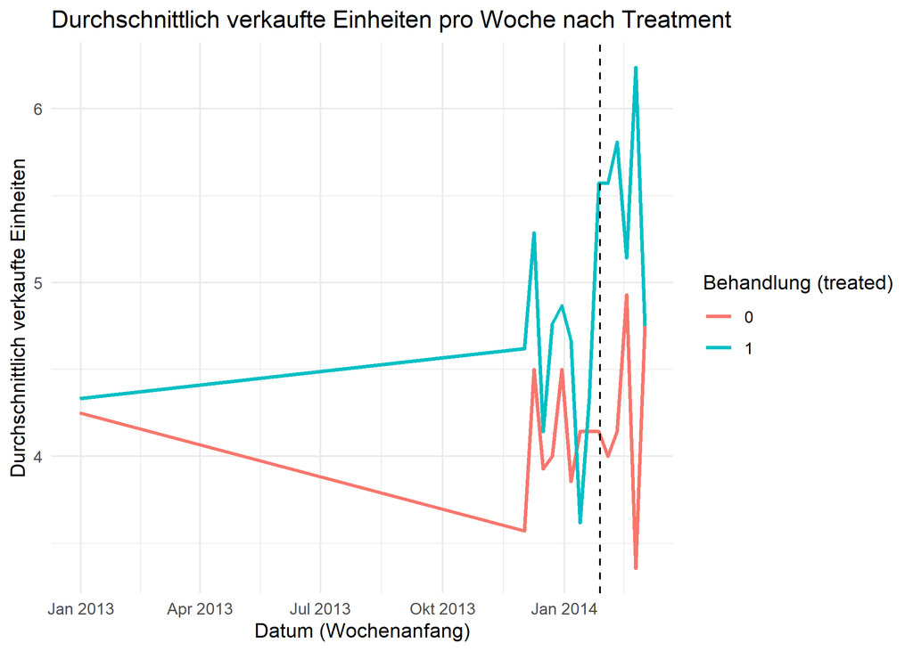

**Beschreibung**

Die Grafik zeigt die durchschnittlich verkauften Einheiten pro Woche für zwei Gruppen: eine Behandlungsgruppe (treated = 1) und eine Kontrollgruppe (treated = 0). Die x-Achse stellt das Datum dar, wobei jede Beobachtung dem Beginn einer Woche entspricht. Die y-Achse zeigt die durchschnittlich verkauften Einheiten.

In der Grafik ist eine vertikale gestrichelte Linie am 28. Januar 2014 eingezeichnet. Diese markiert den Zeitpunkt der Einführung der Kostentransparenzmaßnahme.

Beobachtungen aus der Grafik:

Nach dem 28. Januar 2014 entwickelt sich die Behandlungsgruppe (blau) deutlich anders als die Kontrollgruppe (rot).

**Interpretation**

**Bedeutung gleicher Trends vor dem 28. Januar für Difference-in-Differences:**

Wenn beide Gruppen vor der Einführung der Maßnahme einen gleich starken Anstieg der Verkaufszahlen zeigen, stärkt dies die sogenannte Parallel-Trends-Annahme, die zentrale Voraussetzung für den Difference-in-Differences (DiD)-Ansatz ist.

Diese Annahme bedeutet: Hätte es keine Maßnahme gegeben, wären beide Gruppen auch weiterhin einem gleichen Trend gefolgt. Nur wenn diese Annahme erfüllt ist, kann die Veränderung in der Behandlungsgruppe im Vergleich zur Kontrollgruppe als kausaler Effekt der Maßnahme interpretiert werden.

In diesem Fall würde der sichtbare Unterschied nach dem 28. Januar zwischen den beiden Gruppen dann mit hoher Wahrscheinlichkeit durch die Kostentransparenzmaßnahme verursacht worden sein.

21. Erstellen Sie eine (mehrere) weitere passende Grafik(en), die die durchschnittlich verkauften Einheiten pro Tag in Treatment und Kontrolle vor und nach der Einführung der Kostentransparenz abbildet. Ergänzen Sie in ihrer Grafik die jeweiligen Standardfehler als Fehlerbalken. Beschreiben und interpretieren Sie ihre Grafik. Gehen Sie insbesondere auf die Unterschiede vor und nach der Einführung der Kostentransparenz ein.
- Inwiefern lassen sich daraus erste Hinweise auf einen möglichen Effekt des natürlichen Experiments erkennen?

*Hinweis:* Für die Erstellung der Grafik können Sie sich an Aufgabe 7 und 9 orientieren.

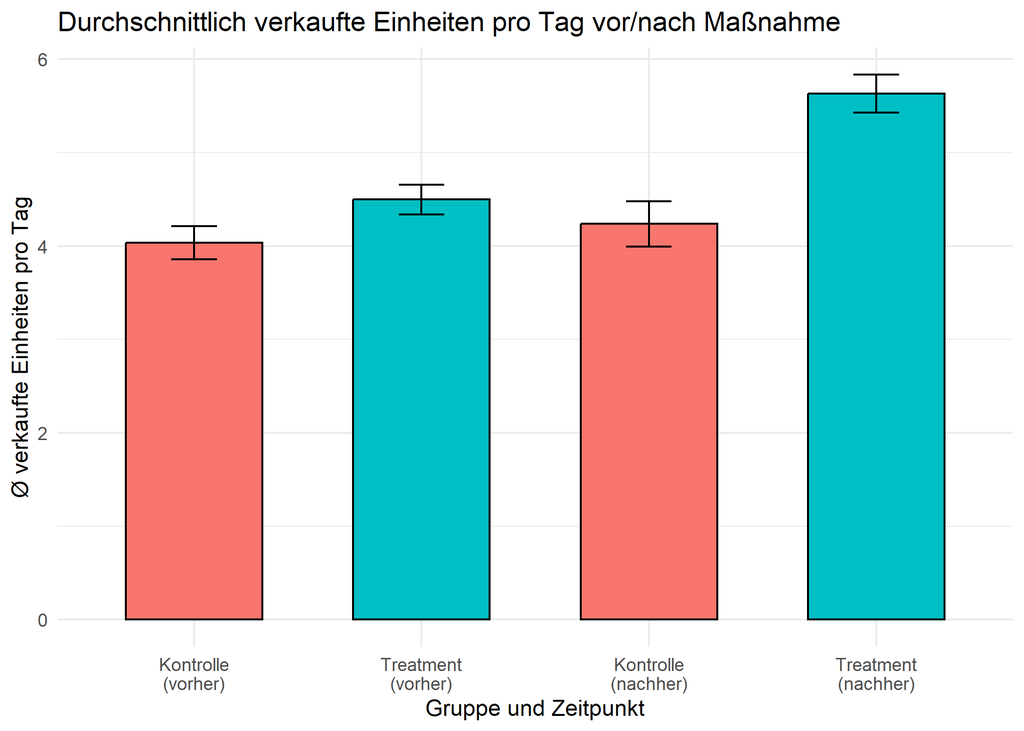

**Beschreibung:**

Die Balkengrafik zeigt die durchschnittlich verkauften Einheiten pro Tag, aufgeteilt nach vier Gruppen: Kontrollgruppe vor der Maßnahme, Treatmentgruppe vor der Maßnahme, Kontrollgruppe nach der Maßnahme und Treatmentgruppe nach der Maßnahme. Jede Gruppe wird durch einen farblich unterschiedlichen Balken dargestellt. Zusätzlich sind Fehlerbalken eingezeichnet, die den Standardfehler des jeweiligen Mittelwerts anzeigen. Die beiden Gruppen (“Kontrolle” und “Treatment”) wurden jeweils vor und nach dem Stichtag (28. Januar) verglichen. Die höchsten durchschnittlichen Verkaufszahlen werden in der Treatmentgruppe nach der Maßnahme beobachtet.

**Interpretation:**

Die Grafik liefert erste visuelle Hinweise auf einen möglichen Effekt des natürlichen Experiments – also der Einführung der Kostentransparenzmaßnahme. Während sich die durchschnittlichen Verkaufszahlen in der Kontrollgruppe vor und nach der Maßnahme kaum verändern, zeigt sich in der Treatmentgruppe ein deutlicher Anstieg nach der Maßnahme. Vor der Einführung lagen die Durchschnittswerte der Treatmentgruppe leicht über denen der Kontrollgruppe. Nach der Maßnahme sticht die Treatmentgruppe jedoch signifikant hervor. Dieser Unterschied in der Veränderung zwischen den Gruppen ist ein typisches Indiz für einen Effekt im Sinne eines Difference-in-Differences-Ansatzes. Sollte sich auch in einer formalen DiD-Analyse zeigen, dass die Trends vor der Maßnahme parallel verliefen, würde das diese visuelle Evidenz stützen und auf eine kausale Wirkung der Kostentransparenz auf die Verkaufszahlen hinweisen.

22. In der vorherigen Aufgabe haben Sie den Effekt von Kostentransparenz auf die Verkaufszahlen anhand eines deskriptiven Vergleichs untersucht. Dabei haben Sie die durchschnittlich täglich verkauften Einheiten je Treatment vor und nach der Einführung der Transparenzmaßnahme grafisch gegenübergestellt. In dieser Aufgabe sollen Sie diesen Effekt nun ökonometrisch genauer untersuchen, indem Sie den Difference-in-Differences Ansatz in einem Regressionsrahmen anwenden.

Untersuchen Sie den Effekt der Einführung von Kostentransparenz auf die Verkaufszahlen mithilfe einer Difference-in-Differences Regression. Verwenden Sie hierfür Beobachtungen an Werktagen, sowie am Wochenende (Montag bis Sonntag), mit positiven Verkaufszahlen.

Erstellen Sie insgesamt zwei Regressionsmodelle:

- Basismodell ohne Kontrollvariablen
- Modell mit Kontrolle für Wochentagseffekte

Stellen Sie die Ergebnisse anschaulich dar. Beschreiben und interpretieren Sie Ihre Ergebnisse. Gehen Sie insbesondere auf folgende Aspekte ein.

- Wie würden Sie die Größe des Effekts interpretieren, den Sie für `treated:post` erhalten haben?
- Welche Vorteile bringt es, log_units (logarithmierte Verkäufe) als abhängige Variable zu verwenden?
- Können Sie aus Ihrer Schätzung auf einen kausalen Effekt der Kostentransparenz schließen?
- Inwiefern hilft die Kontrolle für Wochentage dabei, Verzerrungen in der Schätzung zu vermeiden?
- Würden Sie auf Basis Ihrer Analyse eine Empfehlung zur Beibehaltung oder Ausweitung der Kostentransparenz geben?
- Worin könnten ihrer Ansicht nach Probleme liegen bei der Betrachtung eines natürlichen Experiments, die die Ergebnisse verzerren könnten?

*Hinweis 1:* Nutzen Sie für die Schätzung die `feols()`-Funktion aus dem fixest-Paket.

*Hinweis 2:* Nutzen Sie die logarithmierten täglichen Verkaufszahlen als abhängige Variable.

|  | Basis | Wochentag |
| --- | --- | --- |
| (Intercept) | 1.60*** | 1.60*** |
|  | (0.02) | (0.02) |
| DiD-Indikator (treatment × post) | 0.23*** | 0.23*** |
|  | (0.04) | (0.04) |
| weekday.L |  | -0.07 |
|  |  | (0.05) |
| weekday.Q |  | -0.07 |
|  |  | (0.05) |
| weekday.C |  | -0.01 |
|  |  | (0.05) |
| weekday^4 |  | -0.05 |
|  |  | (0.05) |
| weekday^5 |  | -0.04 |
|  |  | (0.05) |
| weekday^6 |  | 0.10* |
|  |  | (0.05) |
| Num.Obs. | 470 | 470 |
| R2 | 0.060 | 0.080 |
| R2 Adj. | 0.058 | 0.067 |
| AIC | 448.5 | 450.1 |
| BIC | 456.8 | 483.3 |
| RMSE | 0.39 | 0.38 |
| Std.Errors | IID | IID |

+ p < 0.1, * p < 0.05, ** p < 0.01, *** p < 0.001  
Modell Wochentag kontrolliert für den Wochentag

**Beschreibung**

**Interpretation**

Der beobachtete Effekt von rund 26 % zusätzlichen Verkäufen aufgrund der Kostentransparenzmaßnahme ist sowohl statistisch signifikant als auch wirtschaftlich relevant. Dies spricht dafür, dass transparente Information Konsument*innen zusätzliche Sicherheit bei Kaufentscheidungen vermittelt, was in einer deutlich erhöhten Nachfrage resultiert. Die Wahl des natürlichen Logarithmus als abhängige Variable erleichtert die Interpretation der Ergebnisse erheblich, da sie direkt prozentuale Effekte liefert. Zudem reduziert diese Transformation typische Probleme der Heteroskedastizität (ungleiche Streuung der Residuen), was die Vergleichbarkeit und Robustheit der Ergebnisse stärkt.

Der verwendete DiD-Ansatz unterstützt grundsätzlich die Interpretation des Effekts als kausal, jedoch beruht diese stark auf der Annahme paralleler Trends zwischen Kontroll- und Treatmentgruppe vor der Maßnahme. Zur Sicherung der Validität wäre es daher ratsam, ergänzende Trendanalysen oder Placebo-Tests vor Einführung der Transparenzmaßnahme durchzuführen. Außerdem könnten nicht beobachtete externe Einflüsse, etwa Marketingkampagnen oder Lieferengpässe, zu Verzerrungen der Ergebnisse führen. Es ist wichtig, solche Faktoren systematisch zu identifizieren und möglichst zu kontrollieren, um valide Schlussfolgerungen ziehen zu können.

Obwohl die Resultate klar positiv ausfallen, sollte betont werden, dass diese Empfehlung, die Maßnahme dauerhaft beizubehalten, auf einer ersten und vorläufigen Analyse basiert. Langzeitstudien und gezielte, weiterführende Tests sind unbedingt empfehlenswert, um die Robustheit der Ergebnisse langfristig zu sichern. Außerdem könnte eine ergänzende grafische Darstellung, beispielsweise ein Koeffizientenplot, die Ergebnisse klarer und intuitiver vermitteln.

Zusammengefasst lässt sich feststellen, dass die Einführung der Kostentransparenz vorteilhaft erscheint, jedoch bedarf es zusätzlicher Überprüfungsschritte, um langfristige und robuste Empfehlungen abzuleiten.

# Literatur

Mohan, B., Buell, R. W., & John, L. K. (2020). Lifting the veil: The benefits of cost transparency. Marketing Science, 39(6), 1105-1121. https://doi.org/10.1287/mksc.2019.1200

# Anhang

## Mediator

Im Rahmen von Mediationen ist der Mediator eine Variable, die den erklärenden Zusammenhang zwischen einer unabhängigen und einer abhängigen Variable vermittelt. Dabei wird untersucht, inwieweit der Einfluss der unabhängigen Variablen (z.B. Kostentransparenz) auf die abhängige Variable (z.B. Kaufabsicht) über einen vermittelnden Mechanismus - wie das Vertrauen der Kunden - erfolgt.

1. **Mediatoreffekt**: Der Mediatoren-Effekt, oft als ACME (Average Causal Mediation Effect) bezeichnet, beschreibt den indirekten Effekt, den die unabhängige Variable auf die abhängige Variable über den Mediator ausübt. Ist dieser Effekt signifikant, signalisiert dies, dass ein wesentlicher Teil des gesamten Einflusses über den vermittelnden Mechanismus läuft. Gleichzeitig kann ein nicht-signifikanter direkter Effekt (ADE - Average Direct Effect) darauf hindeuten, dass der Mediator den hauptsächlichen Erklärungsmechanismus darstellt.
2. **Funktion und Wirkung des Mediators**: Analog zum Konzept der signalgebenden Funktion bei Statussymbolen - deren Wert unter anderem von der Exklusivität und dem sozialen Kontext abhängt - fungiert der Mediator als vermittelnder Kanal, der erklärt, wie und warum der ursprüngliche Zusammenhang zwischen zwei Variablen zustande kommt. Der Mediator „überträgt“ quasi den Effekt der unabhängigen Variable auf die abhängige Variable. Dadurch kann in Modellen, in denen der direkte Zusammenhang zwischen der unabhängigen und der abhängigen Variable durch die Einbeziehung des Mediators verschwindet oder abgeschwächt wird, abgeleitet werden, dass der Mechanismus über den Mediator läuft. Dies ermöglicht ein tieferes Verständnis der zugrundeliegenden psychologischen Prozesse - etwa wie das Vertrauen der Kunden die Wirkung von Kostentransparenz auf deren Kaufabsicht vermittelt.

Zusammengefasst spielt der Mediator eine zentrale Rolle bei der Aufklärung der kausalen Mechanismen, indem er als vermittelnder Faktor zwischen Ursache und Wirkung identifiziert wird. Die signifikante Vermittlung über den Mediator zeigt, dass nicht allein das Vorhandensein von Kostentransparenz entscheidend ist, sondern auch, inwiefern diese Transparenz das Vertrauen stärkt - was wiederum maßgeblich die Kaufabsicht beeinflusst. So liefert die Mediationsanalyse wertvolle Einsichten, die über einfache bivariate Zusammenhänge hinausgehen und die Komplexität kausaler Mechanismen innerhalb von sozialen oder marktorientierten Prozessen sichtbar machen.

## Informationen zum Studiendesign des Experiments 1 und 2

[output not shown]